# PREDICTING RETAIL STORE SALES WITH XGBOOST

### **Author:** Manenimabasi Martin Udoh

### **Institution:** Covenant University

### **Abstract:**

The primary objective of this study is to develop accurate predictive models that can inform decision-making processes and offer valuable recommendations for enhancing future business operations. The project employs XGBoost, a powerful ensemble learning algorithm, and utilizes the computational capabilities of Amazon SageMaker to build and evaluate the models.

The project's findings showcase the effectiveness of XGBoost in achieving accurate sales predictions. The model achieved impressive performance with key metrics such as Root Mean Squared Error (RMSE), Mean Squared Error (MSE), and Mean Absolute Error (MAE), demonstrating its precision in forecasting sales. Furthermore, the high R-squared (R2) value of 0.9002 and adjusted R-squared (Adjusted R2) value of 0.8997 underscore the model's ability to explain a significant portion of the variance in sales.

These results have profound implications for the retail industry, offering opportunities for optimized inventory management, staffing decisions, and marketing strategies. Furthermore, the project underscores the significance of ensemble learning, regularization techniques, and cloud-based machine learning in addressing real-world sales forecasting challenges.

In conclusion, this project exemplifies the potential of data-driven decision-making in the retail sector, providing actionable insights into enhancing business processes and driving revenue growth.

**Keywords:** XGBoost, Sales Prediction, Comparative Analysis, Machine Learning, Regression

- INTRODUCTION
- IMPORTS AND SETUP
- DATA EXPLORATION
- MERGING DATASETS
- EXPLORING MERGED DATASET
- EXPLORATORY DATA ANALYSIS
- DATA VISUALIZATION
- DATA PREPROCESSING
- TRAINING XGBOOST REGRESSOR
- DEPLOYMENT AND PREDICTIONS
- RESULTS AND DISCUSSION
- CONCLUSION AND RECOMMENDATIONS
- REFERENCES

**Contact Information:**

- **Email:** manenimabasi.udoh@stu.cu.edu.ng
- **LinkedIn:** [manenimabasi-udoh](https://www.linkedin.com/in/manenimabasi-udoh-42b480253/)
- **GitHub:** manenim

# INTRODUCTION

Retail businesses thrive on the ability to anticipate customer demand and optimize their operations accordingly. Accurate sales forecasting plays a pivotal role in achieving this goal. In this project, we delve into the realm of retail analytics to develop predictive models for forecasting weekly sales in a retail store.

The significance of this project lies in its potential to inform data-driven decision-making within the retail industry. Accurate sales predictions empower businesses to make informed choices about inventory management, staffing levels, and marketing strategies. This, in turn, can lead to increased operational efficiency and revenue generation.

Our approach combines cutting-edge machine learning techniques, specifically XGBoost, with the computational capabilities of Amazon SageMaker. Through this synergy, we aim to demonstrate the power of ensemble learning, regularization methods, and cloud-based machine learning in addressing real-world sales forecasting challenges.

In the following sections, we will delve into the project's methodology, key findings, and implications for the retail industry, showcasing how data-driven insights can drive success and enhance business operations.

# IMPORTS AND SETUP

```python
import pandas as pd
import numpy as np
import seaborn as sns
import matplotlib.pyplot as plt
import zipfile
```

```python
# importing the csv files using pandas
feature = pd.read_csv('Features_data_set.csv')
sales = pd.read_csv('sales_data_set.csv')
stores = pd.read_csv('stores_data_set.csv')
```

```python
# exploring the data
# "stores" dataframe contains information related to the 45 stores such as type and size of store.

stores
```

|  | Store | Type | Size |
| --- | --- | --- | --- |
| 0 | 1 | A | 151315 |
| 1 | 2 | A | 202307 |
| 2 | 3 | B | 37392 |
| 3 | 4 | A | 205863 |
| 4 | 5 | B | 34875 |
| 5 | 6 | A | 202505 |
| 6 | 7 | B | 70713 |
| 7 | 8 | A | 155078 |
| 8 | 9 | B | 125833 |
| 9 | 10 | B | 126512 |
| 10 | 11 | A | 207499 |
| 11 | 12 | B | 112238 |
| 12 | 13 | A | 219622 |
| 13 | 14 | A | 200898 |
| 14 | 15 | B | 123737 |
| 15 | 16 | B | 57197 |
| 16 | 17 | B | 93188 |
| 17 | 18 | B | 120653 |
| 18 | 19 | A | 203819 |
| 19 | 20 | A | 203742 |
| 20 | 21 | B | 140167 |
| 21 | 22 | B | 119557 |
| 22 | 23 | B | 114533 |
| 23 | 24 | A | 203819 |
| 24 | 25 | B | 128107 |
| 25 | 26 | A | 152513 |
| 26 | 27 | A | 204184 |
| 27 | 28 | A | 206302 |
| 28 | 29 | B | 93638 |
| 29 | 30 | C | 42988 |
| 30 | 31 | A | 203750 |
| 31 | 32 | A | 203007 |
| 32 | 33 | A | 39690 |
| 33 | 34 | A | 158114 |
| 34 | 35 | B | 103681 |
| 35 | 36 | A | 39910 |
| 36 | 37 | C | 39910 |
| 37 | 38 | C | 39690 |
| 38 | 39 | A | 184109 |
| 39 | 40 | A | 155083 |
| 40 | 41 | A | 196321 |
| 41 | 42 | C | 39690 |
| 42 | 43 | C | 41062 |
| 43 | 44 | C | 39910 |
| 44 | 45 | B | 118221 |

```python
# Features dataframe contains additional data related to the store, department, and regional activity for the given dates.
# Store: store number
# Date: week
# Temperature: average temperature in the region
# Fuel_Price: cost of fuel in the region
# MarkDown1-5: anonymized data related to promotional markdowns.
# CPI: consumer price index
# Unemployment: unemployment rate
# IsHoliday: whether the week is a special holiday week or not

feature
```

|  | Store | Date | Temperature | Fuel_Price | MarkDown1 | MarkDown2 | MarkDown3 | MarkDown4 | MarkDown5 | CPI | Unemployment | IsHoliday |
| --- | --- | --- | --- | --- | --- | --- | --- | --- | --- | --- | --- | --- |
| 0 | 1 | 05/02/2010 | 42.31 | 2.572 | NaN | NaN | NaN | NaN | NaN | 211.096358 | 8.106 | False |
| 1 | 1 | 12/02/2010 | 38.51 | 2.548 | NaN | NaN | NaN | NaN | NaN | 211.242170 | 8.106 | True |
| 2 | 1 | 19/02/2010 | 39.93 | 2.514 | NaN | NaN | NaN | NaN | NaN | 211.289143 | 8.106 | False |
| 3 | 1 | 26/02/2010 | 46.63 | 2.561 | NaN | NaN | NaN | NaN | NaN | 211.319643 | 8.106 | False |
| 4 | 1 | 05/03/2010 | 46.50 | 2.625 | NaN | NaN | NaN | NaN | NaN | 211.350143 | 8.106 | False |
| ... | ... | ... | ... | ... | ... | ... | ... | ... | ... | ... | ... | ... |
| 8185 | 45 | 28/06/2013 | 76.05 | 3.639 | 4842.29 | 975.03 | 3.00 | 2449.97 | 3169.69 | NaN | NaN | False |
| 8186 | 45 | 05/07/2013 | 77.50 | 3.614 | 9090.48 | 2268.58 | 582.74 | 5797.47 | 1514.93 | NaN | NaN | False |
| 8187 | 45 | 12/07/2013 | 79.37 | 3.614 | 3789.94 | 1827.31 | 85.72 | 744.84 | 2150.36 | NaN | NaN | False |
| 8188 | 45 | 19/07/2013 | 82.84 | 3.737 | 2961.49 | 1047.07 | 204.19 | 363.00 | 1059.46 | NaN | NaN | False |
| 8189 | 45 | 26/07/2013 | 76.06 | 3.804 | 212.02 | 851.73 | 2.06 | 10.88 | 1864.57 | NaN | NaN | False |

8190 rows × 12 columns

```python
# exploring the "sales" dataframe
# "Sales" dataframe contains historical sales data, which covers 2010-02-05 to 2012-11-01.
# Store: store number
# Dept: department number
# Date: the week
# Weekly_Sales: sales for the given department in the given store
# IsHoliday: whether the week is a special holiday week

sales
```

|  | Store | Dept | Date | Weekly_Sales | IsHoliday |
| --- | --- | --- | --- | --- | --- |
| 0 | 1 | 1 | 05/02/2010 | 24924.50 | False |
| 1 | 1 | 1 | 12/02/2010 | 46039.49 | True |
| 2 | 1 | 1 | 19/02/2010 | 41595.55 | False |
| 3 | 1 | 1 | 26/02/2010 | 19403.54 | False |
| 4 | 1 | 1 | 05/03/2010 | 21827.90 | False |
| ... | ... | ... | ... | ... | ... |
| 421565 | 45 | 98 | 28/09/2012 | 508.37 | False |
| 421566 | 45 | 98 | 05/10/2012 | 628.10 | False |
| 421567 | 45 | 98 | 12/10/2012 | 1061.02 | False |
| 421568 | 45 | 98 | 19/10/2012 | 760.01 | False |
| 421569 | 45 | 98 | 26/10/2012 | 1076.80 | False |

421570 rows × 5 columns

# DATA EXPLORATION

```python
sales.info()
```

```
<class 'pandas.core.frame.DataFrame'>
RangeIndex: 421570 entries, 0 to 421569
Data columns (total 5 columns):
 #   Column        Non-Null Count   Dtype
---  ------        --------------   -----
 0   Store         421570 non-null  int64
 1   Dept          421570 non-null  int64
 2   Date          421570 non-null  object
 3   Weekly_Sales  421570 non-null  float64
 4   IsHoliday     421570 non-null  bool
dtypes: bool(1), float64(1), int64(2), object(1)
memory usage: 13.3+ MB
```

```python
sales.describe()
```

|  | Store | Dept | Weekly_Sales |
| --- | --- | --- | --- |
| count | 421570.000000 | 421570.000000 | 421570.000000 |
| mean | 22.200546 | 44.260317 | 15981.258123 |
| std | 12.785297 | 30.492054 | 22711.183519 |
| min | 1.000000 | 1.000000 | -4988.940000 |
| 25% | 11.000000 | 18.000000 | 2079.650000 |
| 50% | 22.000000 | 37.000000 | 7612.030000 |
| 75% | 33.000000 | 74.000000 | 20205.852500 |
| max | 45.000000 | 99.000000 | 693099.360000 |

```python
feature.info()
```

```
<class 'pandas.core.frame.DataFrame'>
RangeIndex: 8190 entries, 0 to 8189
Data columns (total 12 columns):
 #   Column        Non-Null Count  Dtype
---  ------        --------------  -----
 0   Store         8190 non-null   int64
 1   Date          8190 non-null   object
 2   Temperature   8190 non-null   float64
 3   Fuel_Price    8190 non-null   float64
 4   MarkDown1     4032 non-null   float64
 5   MarkDown2     2921 non-null   float64
 6   MarkDown3     3613 non-null   float64
 7   MarkDown4     3464 non-null   float64
 8   MarkDown5     4050 non-null   float64
 9   CPI           7605 non-null   float64
 10  Unemployment  7605 non-null   float64
 11  IsHoliday     8190 non-null   bool
dtypes: bool(1), float64(9), int64(1), object(1)
memory usage: 712.0+ KB
```

```python
feature.describe()
```

|  | Store | Temperature | Fuel_Price | MarkDown1 | MarkDown2 | MarkDown3 | MarkDown4 | MarkDown5 | CPI | Unemployment |
| --- | --- | --- | --- | --- | --- | --- | --- | --- | --- | --- |
| count | 8190.000000 | 8190.000000 | 8190.000000 | 4032.000000 | 2921.000000 | 3613.000000 | 3464.000000 | 4050.000000 | 7605.000000 | 7605.000000 |
| mean | 23.000000 | 59.356198 | 3.405992 | 7032.371786 | 3384.176594 | 1760.100180 | 3292.935886 | 4132.216422 | 172.460809 | 7.826821 |
| std | 12.987966 | 18.678607 | 0.431337 | 9262.747448 | 8793.583016 | 11276.462208 | 6792.329861 | 13086.690278 | 39.738346 | 1.877259 |
| min | 1.000000 | -7.290000 | 2.472000 | -2781.450000 | -265.760000 | -179.260000 | 0.220000 | -185.170000 | 126.064000 | 3.684000 |
| 25% | 12.000000 | 45.902500 | 3.041000 | 1577.532500 | 68.880000 | 6.600000 | 304.687500 | 1440.827500 | 132.364839 | 6.634000 |
| 50% | 23.000000 | 60.710000 | 3.513000 | 4743.580000 | 364.570000 | 36.260000 | 1176.425000 | 2727.135000 | 182.764003 | 7.806000 |
| 75% | 34.000000 | 73.880000 | 3.743000 | 8923.310000 | 2153.350000 | 163.150000 | 3310.007500 | 4832.555000 | 213.932412 | 8.567000 |
| max | 45.000000 | 101.950000 | 4.468000 | 103184.980000 | 104519.540000 | 149483.310000 | 67474.850000 | 771448.100000 | 228.976456 | 14.313000 |

```python
stores.info()
```

```
<class 'pandas.core.frame.DataFrame'>
RangeIndex: 45 entries, 0 to 44
Data columns (total 3 columns):
 #   Column  Non-Null Count  Dtype
---  ------  --------------  -----
 0   Store   45 non-null     int64
 1   Type    45 non-null     object
 2   Size    45 non-null     int64
dtypes: int64(2), object(1)
memory usage: 1.2+ KB
```

```python
stores.describe()
```

|  | Store | Size |
| --- | --- | --- |
| count | 45.000000 | 45.000000 |
| mean | 23.000000 | 130287.600000 |
| std | 13.133926 | 63825.271991 |
| min | 1.000000 | 34875.000000 |
| 25% | 12.000000 | 70713.000000 |
| 50% | 23.000000 | 126512.000000 |
| 75% | 34.000000 | 202307.000000 |
| max | 45.000000 | 219622.000000 |

```python
# Change the datatype of 'date' column
```

```python
feature['Date'] = pd.to_datetime(feature['Date'], format='mixed')
sales['Date'] = pd.to_datetime(sales['Date'], format='mixed')
```

```python
feature
```

|  | Store | Date | Temperature | Fuel_Price | MarkDown1 | MarkDown2 | MarkDown3 | MarkDown4 | MarkDown5 | CPI | Unemployment | IsHoliday |
| --- | --- | --- | --- | --- | --- | --- | --- | --- | --- | --- | --- | --- |
| 0 | 1 | 2010-05-02 | 42.31 | 2.572 | NaN | NaN | NaN | NaN | NaN | 211.096358 | 8.106 | False |
| 1 | 1 | 2010-12-02 | 38.51 | 2.548 | NaN | NaN | NaN | NaN | NaN | 211.242170 | 8.106 | True |
| 2 | 1 | 2010-02-19 | 39.93 | 2.514 | NaN | NaN | NaN | NaN | NaN | 211.289143 | 8.106 | False |
| 3 | 1 | 2010-02-26 | 46.63 | 2.561 | NaN | NaN | NaN | NaN | NaN | 211.319643 | 8.106 | False |
| 4 | 1 | 2010-05-03 | 46.50 | 2.625 | NaN | NaN | NaN | NaN | NaN | 211.350143 | 8.106 | False |
| ... | ... | ... | ... | ... | ... | ... | ... | ... | ... | ... | ... | ... |
| 8185 | 45 | 2013-06-28 | 76.05 | 3.639 | 4842.29 | 975.03 | 3.00 | 2449.97 | 3169.69 | NaN | NaN | False |
| 8186 | 45 | 2013-05-07 | 77.50 | 3.614 | 9090.48 | 2268.58 | 582.74 | 5797.47 | 1514.93 | NaN | NaN | False |
| 8187 | 45 | 2013-12-07 | 79.37 | 3.614 | 3789.94 | 1827.31 | 85.72 | 744.84 | 2150.36 | NaN | NaN | False |
| 8188 | 45 | 2013-07-19 | 82.84 | 3.737 | 2961.49 | 1047.07 | 204.19 | 363.00 | 1059.46 | NaN | NaN | False |
| 8189 | 45 | 2013-07-26 | 76.06 | 3.804 | 212.02 | 851.73 | 2.06 | 10.88 | 1864.57 | NaN | NaN | False |

8190 rows × 12 columns

```python
sales
```

|  | Store | Dept | Date | Weekly_Sales | IsHoliday |
| --- | --- | --- | --- | --- | --- |
| 0 | 1 | 1 | 2010-05-02 | 24924.50 | False |
| 1 | 1 | 1 | 2010-12-02 | 46039.49 | True |
| 2 | 1 | 1 | 2010-02-19 | 41595.55 | False |
| 3 | 1 | 1 | 2010-02-26 | 19403.54 | False |
| 4 | 1 | 1 | 2010-05-03 | 21827.90 | False |
| ... | ... | ... | ... | ... | ... |
| 421565 | 45 | 98 | 2012-09-28 | 508.37 | False |
| 421566 | 45 | 98 | 2012-05-10 | 628.10 | False |
| 421567 | 45 | 98 | 2012-12-10 | 1061.02 | False |
| 421568 | 45 | 98 | 2012-10-19 | 760.01 | False |
| 421569 | 45 | 98 | 2012-10-26 | 1076.80 | False |

421570 rows × 5 columns

# MERGING DATASETS

```python
sales.head()
```

|  | Store | Dept | Date | Weekly_Sales | IsHoliday |
| --- | --- | --- | --- | --- | --- |
| 0 | 1 | 1 | 2010-05-02 | 24924.50 | False |
| 1 | 1 | 1 | 2010-12-02 | 46039.49 | True |
| 2 | 1 | 1 | 2010-02-19 | 41595.55 | False |
| 3 | 1 | 1 | 2010-02-26 | 19403.54 | False |
| 4 | 1 | 1 | 2010-05-03 | 21827.90 | False |

```python
feature.head()
```

|  | Store | Date | Temperature | Fuel_Price | MarkDown1 | MarkDown2 | MarkDown3 | MarkDown4 | MarkDown5 | CPI | Unemployment | IsHoliday |
| --- | --- | --- | --- | --- | --- | --- | --- | --- | --- | --- | --- | --- |
| 0 | 1 | 2010-05-02 | 42.31 | 2.572 | NaN | NaN | NaN | NaN | NaN | 211.096358 | 8.106 | False |
| 1 | 1 | 2010-12-02 | 38.51 | 2.548 | NaN | NaN | NaN | NaN | NaN | 211.242170 | 8.106 | True |
| 2 | 1 | 2010-02-19 | 39.93 | 2.514 | NaN | NaN | NaN | NaN | NaN | 211.289143 | 8.106 | False |
| 3 | 1 | 2010-02-26 | 46.63 | 2.561 | NaN | NaN | NaN | NaN | NaN | 211.319643 | 8.106 | False |
| 4 | 1 | 2010-05-03 | 46.50 | 2.625 | NaN | NaN | NaN | NaN | NaN | 211.350143 | 8.106 | False |

```python
df = pd.merge(sales, feature, on = ['Store','Date','IsHoliday'])
```

```python
df
```

|  | Store | Dept | Date | Weekly_Sales | IsHoliday | Temperature | Fuel_Price | MarkDown1 | MarkDown2 | MarkDown3 | MarkDown4 | MarkDown5 | CPI | Unemployment |
| --- | --- | --- | --- | --- | --- | --- | --- | --- | --- | --- | --- | --- | --- | --- |
| 0 | 1 | 1 | 2010-05-02 | 24924.50 | False | 42.31 | 2.572 | NaN | NaN | NaN | NaN | NaN | 211.096358 | 8.106 |
| 1 | 1 | 2 | 2010-05-02 | 50605.27 | False | 42.31 | 2.572 | NaN | NaN | NaN | NaN | NaN | 211.096358 | 8.106 |
| 2 | 1 | 3 | 2010-05-02 | 13740.12 | False | 42.31 | 2.572 | NaN | NaN | NaN | NaN | NaN | 211.096358 | 8.106 |
| 3 | 1 | 4 | 2010-05-02 | 39954.04 | False | 42.31 | 2.572 | NaN | NaN | NaN | NaN | NaN | 211.096358 | 8.106 |
| 4 | 1 | 5 | 2010-05-02 | 32229.38 | False | 42.31 | 2.572 | NaN | NaN | NaN | NaN | NaN | 211.096358 | 8.106 |
| ... | ... | ... | ... | ... | ... | ... | ... | ... | ... | ... | ... | ... | ... | ... |
| 421565 | 45 | 93 | 2012-10-26 | 2487.80 | False | 58.85 | 3.882 | 4018.91 | 58.08 | 100.0 | 211.94 | 858.33 | 192.308899 | 8.667 |
| 421566 | 45 | 94 | 2012-10-26 | 5203.31 | False | 58.85 | 3.882 | 4018.91 | 58.08 | 100.0 | 211.94 | 858.33 | 192.308899 | 8.667 |
| 421567 | 45 | 95 | 2012-10-26 | 56017.47 | False | 58.85 | 3.882 | 4018.91 | 58.08 | 100.0 | 211.94 | 858.33 | 192.308899 | 8.667 |
| 421568 | 45 | 97 | 2012-10-26 | 6817.48 | False | 58.85 | 3.882 | 4018.91 | 58.08 | 100.0 | 211.94 | 858.33 | 192.308899 | 8.667 |
| 421569 | 45 | 98 | 2012-10-26 | 1076.80 | False | 58.85 | 3.882 | 4018.91 | 58.08 | 100.0 | 211.94 | 858.33 | 192.308899 | 8.667 |

421570 rows × 14 columns

```python
df.head()
```

|  | Store | Dept | Date | Weekly_Sales | IsHoliday | Temperature | Fuel_Price | MarkDown1 | MarkDown2 | MarkDown3 | MarkDown4 | MarkDown5 | CPI | Unemployment |
| --- | --- | --- | --- | --- | --- | --- | --- | --- | --- | --- | --- | --- | --- | --- |
| 0 | 1 | 1 | 2010-05-02 | 24924.50 | False | 42.31 | 2.572 | NaN | NaN | NaN | NaN | NaN | 211.096358 | 8.106 |
| 1 | 1 | 2 | 2010-05-02 | 50605.27 | False | 42.31 | 2.572 | NaN | NaN | NaN | NaN | NaN | 211.096358 | 8.106 |
| 2 | 1 | 3 | 2010-05-02 | 13740.12 | False | 42.31 | 2.572 | NaN | NaN | NaN | NaN | NaN | 211.096358 | 8.106 |
| 3 | 1 | 4 | 2010-05-02 | 39954.04 | False | 42.31 | 2.572 | NaN | NaN | NaN | NaN | NaN | 211.096358 | 8.106 |
| 4 | 1 | 5 | 2010-05-02 | 32229.38 | False | 42.31 | 2.572 | NaN | NaN | NaN | NaN | NaN | 211.096358 | 8.106 |

```python
stores.head()
```

|  | Store | Type | Size |
| --- | --- | --- | --- |
| 0 | 1 | A | 151315 |
| 1 | 2 | A | 202307 |
| 2 | 3 | B | 37392 |
| 3 | 4 | A | 205863 |
| 4 | 5 | B | 34875 |

```python
df = pd.merge(df, stores, on = ['Store'], how = 'left')
```

```python
df.head()
```

|  | Store | Dept | Date | Weekly_Sales | IsHoliday | Temperature | Fuel_Price | MarkDown1 | MarkDown2 | MarkDown3 | MarkDown4 | MarkDown5 | CPI | Unemployment | Type | Size |
| --- | --- | --- | --- | --- | --- | --- | --- | --- | --- | --- | --- | --- | --- | --- | --- | --- |
| 0 | 1 | 1 | 2010-05-02 | 24924.50 | False | 42.31 | 2.572 | NaN | NaN | NaN | NaN | NaN | 211.096358 | 8.106 | A | 151315 |
| 1 | 1 | 2 | 2010-05-02 | 50605.27 | False | 42.31 | 2.572 | NaN | NaN | NaN | NaN | NaN | 211.096358 | 8.106 | A | 151315 |
| 2 | 1 | 3 | 2010-05-02 | 13740.12 | False | 42.31 | 2.572 | NaN | NaN | NaN | NaN | NaN | 211.096358 | 8.106 | A | 151315 |
| 3 | 1 | 4 | 2010-05-02 | 39954.04 | False | 42.31 | 2.572 | NaN | NaN | NaN | NaN | NaN | 211.096358 | 8.106 | A | 151315 |
| 4 | 1 | 5 | 2010-05-02 | 32229.38 | False | 42.31 | 2.572 | NaN | NaN | NaN | NaN | NaN | 211.096358 | 8.106 | A | 151315 |

- Define a function to extract the month information from the dataframe column "Date"
- Apply the function to the entire column "Date" in the merged dataframe "df" and write the output in a column entitled "month"

```python
def get_month(x):
    return int(str(x).split('-')[1])
```

```python
df['Month'] = df['Date'].apply(get_month)
```

```python
df
```

|  | Store | Dept | Date | Weekly_Sales | IsHoliday | Temperature | Fuel_Price | MarkDown1 | MarkDown2 | MarkDown3 | MarkDown4 | MarkDown5 | CPI | Unemployment | Type | Size | Month |
| --- | --- | --- | --- | --- | --- | --- | --- | --- | --- | --- | --- | --- | --- | --- | --- | --- | --- |
| 0 | 1 | 1 | 2010-05-02 | 24924.50 | False | 42.31 | 2.572 | NaN | NaN | NaN | NaN | NaN | 211.096358 | 8.106 | A | 151315 | 5 |
| 1 | 1 | 2 | 2010-05-02 | 50605.27 | False | 42.31 | 2.572 | NaN | NaN | NaN | NaN | NaN | 211.096358 | 8.106 | A | 151315 | 5 |
| 2 | 1 | 3 | 2010-05-02 | 13740.12 | False | 42.31 | 2.572 | NaN | NaN | NaN | NaN | NaN | 211.096358 | 8.106 | A | 151315 | 5 |
| 3 | 1 | 4 | 2010-05-02 | 39954.04 | False | 42.31 | 2.572 | NaN | NaN | NaN | NaN | NaN | 211.096358 | 8.106 | A | 151315 | 5 |
| 4 | 1 | 5 | 2010-05-02 | 32229.38 | False | 42.31 | 2.572 | NaN | NaN | NaN | NaN | NaN | 211.096358 | 8.106 | A | 151315 | 5 |
| ... | ... | ... | ... | ... | ... | ... | ... | ... | ... | ... | ... | ... | ... | ... | ... | ... | ... |
| 421565 | 45 | 93 | 2012-10-26 | 2487.80 | False | 58.85 | 3.882 | 4018.91 | 58.08 | 100.0 | 211.94 | 858.33 | 192.308899 | 8.667 | B | 118221 | 10 |
| 421566 | 45 | 94 | 2012-10-26 | 5203.31 | False | 58.85 | 3.882 | 4018.91 | 58.08 | 100.0 | 211.94 | 858.33 | 192.308899 | 8.667 | B | 118221 | 10 |
| 421567 | 45 | 95 | 2012-10-26 | 56017.47 | False | 58.85 | 3.882 | 4018.91 | 58.08 | 100.0 | 211.94 | 858.33 | 192.308899 | 8.667 | B | 118221 | 10 |
| 421568 | 45 | 97 | 2012-10-26 | 6817.48 | False | 58.85 | 3.882 | 4018.91 | 58.08 | 100.0 | 211.94 | 858.33 | 192.308899 | 8.667 | B | 118221 | 10 |
| 421569 | 45 | 98 | 2012-10-26 | 1076.80 | False | 58.85 | 3.882 | 4018.91 | 58.08 | 100.0 | 211.94 | 858.33 | 192.308899 | 8.667 | B | 118221 | 10 |

421570 rows × 17 columns

# EXPLORING MERGED DATASET

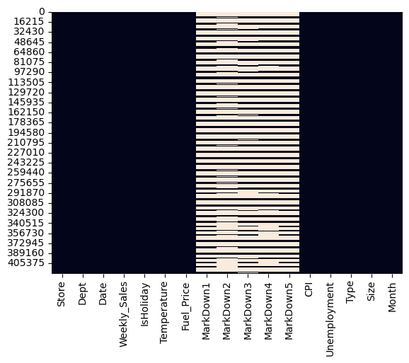

```python
sns.heatmap(df.isnull(), cbar = False)
```

```python
# check the number of non-null values in the dataframe
df.isnull().sum()
```

```
Store                0
Dept                 0
Date                 0
Weekly_Sales         0
IsHoliday            0
Temperature          0
Fuel_Price           0
MarkDown1       270889
MarkDown2       310322
MarkDown3       284479
MarkDown4       286603
MarkDown5       270138
CPI                  0
Unemployment         0
Type                 0
Size                 0
Month                0
dtype: int64
```

```python
# Fill up NaN elements with zeros
df = df.fillna(0)
```

```python
df
```

|  | Store | Dept | Date | Weekly_Sales | IsHoliday | Temperature | Fuel_Price | MarkDown1 | MarkDown2 | MarkDown3 | MarkDown4 | MarkDown5 | CPI | Unemployment | Type | Size | Month |
| --- | --- | --- | --- | --- | --- | --- | --- | --- | --- | --- | --- | --- | --- | --- | --- | --- | --- |
| 0 | 1 | 1 | 2010-05-02 | 24924.50 | False | 42.31 | 2.572 | 0.00 | 0.00 | 0.0 | 0.00 | 0.00 | 211.096358 | 8.106 | A | 151315 | 5 |
| 1 | 1 | 2 | 2010-05-02 | 50605.27 | False | 42.31 | 2.572 | 0.00 | 0.00 | 0.0 | 0.00 | 0.00 | 211.096358 | 8.106 | A | 151315 | 5 |
| 2 | 1 | 3 | 2010-05-02 | 13740.12 | False | 42.31 | 2.572 | 0.00 | 0.00 | 0.0 | 0.00 | 0.00 | 211.096358 | 8.106 | A | 151315 | 5 |
| 3 | 1 | 4 | 2010-05-02 | 39954.04 | False | 42.31 | 2.572 | 0.00 | 0.00 | 0.0 | 0.00 | 0.00 | 211.096358 | 8.106 | A | 151315 | 5 |
| 4 | 1 | 5 | 2010-05-02 | 32229.38 | False | 42.31 | 2.572 | 0.00 | 0.00 | 0.0 | 0.00 | 0.00 | 211.096358 | 8.106 | A | 151315 | 5 |
| ... | ... | ... | ... | ... | ... | ... | ... | ... | ... | ... | ... | ... | ... | ... | ... | ... | ... |
| 421565 | 45 | 93 | 2012-10-26 | 2487.80 | False | 58.85 | 3.882 | 4018.91 | 58.08 | 100.0 | 211.94 | 858.33 | 192.308899 | 8.667 | B | 118221 | 10 |
| 421566 | 45 | 94 | 2012-10-26 | 5203.31 | False | 58.85 | 3.882 | 4018.91 | 58.08 | 100.0 | 211.94 | 858.33 | 192.308899 | 8.667 | B | 118221 | 10 |
| 421567 | 45 | 95 | 2012-10-26 | 56017.47 | False | 58.85 | 3.882 | 4018.91 | 58.08 | 100.0 | 211.94 | 858.33 | 192.308899 | 8.667 | B | 118221 | 10 |
| 421568 | 45 | 97 | 2012-10-26 | 6817.48 | False | 58.85 | 3.882 | 4018.91 | 58.08 | 100.0 | 211.94 | 858.33 | 192.308899 | 8.667 | B | 118221 | 10 |
| 421569 | 45 | 98 | 2012-10-26 | 1076.80 | False | 58.85 | 3.882 | 4018.91 | 58.08 | 100.0 | 211.94 | 858.33 | 192.308899 | 8.667 | B | 118221 | 10 |

421570 rows × 17 columns

```python
# Statistical summary of the combined dataframe
df.describe()
```

|  | Store | Dept | Date | Weekly_Sales | Temperature | Fuel_Price | MarkDown1 | MarkDown2 | MarkDown3 | MarkDown4 | MarkDown5 | CPI | Unemployment | Size | Month |
| --- | --- | --- | --- | --- | --- | --- | --- | --- | --- | --- | --- | --- | --- | --- | --- |
| count | 421570.000000 | 421570.000000 | 421570 | 421570.000000 | 421570.000000 | 421570.000000 | 421570.000000 | 421570.000000 | 421570.000000 | 421570.000000 | 421570.000000 | 421570.000000 | 421570.000000 | 421570.000000 | 421570.000000 |
| mean | 22.200546 | 44.260317 | 2011-06-19 05:35:51.733757440 | 15981.258123 | 60.090059 | 3.361027 | 2590.074819 | 879.974298 | 468.087665 | 1083.132268 | 1662.772385 | 171.201947 | 7.960289 | 136727.915739 | 6.478580 |
| min | 1.000000 | 1.000000 | 2010-01-10 00:00:00 | -4988.940000 | -2.060000 | 2.472000 | 0.000000 | -265.760000 | -29.100000 | 0.000000 | 0.000000 | 126.064000 | 3.879000 | 34875.000000 | 1.000000 |
| 25% | 11.000000 | 18.000000 | 2010-10-12 00:00:00 | 2079.650000 | 46.680000 | 2.933000 | 0.000000 | 0.000000 | 0.000000 | 0.000000 | 0.000000 | 132.022667 | 6.891000 | 93638.000000 | 4.000000 |
| 50% | 22.000000 | 37.000000 | 2011-06-17 00:00:00 | 7612.030000 | 62.090000 | 3.452000 | 0.000000 | 0.000000 | 0.000000 | 0.000000 | 0.000000 | 182.318780 | 7.866000 | 140167.000000 | 6.000000 |
| 75% | 33.000000 | 74.000000 | 2012-03-02 00:00:00 | 20205.852500 | 74.280000 | 3.738000 | 2809.050000 | 2.200000 | 4.540000 | 425.290000 | 2168.040000 | 212.416993 | 8.572000 | 202505.000000 | 9.000000 |
| max | 45.000000 | 99.000000 | 2012-12-10 00:00:00 | 693099.360000 | 100.140000 | 4.468000 | 88646.760000 | 104519.540000 | 141630.610000 | 67474.850000 | 108519.280000 | 227.232807 | 14.313000 | 219622.000000 | 12.000000 |
| std | 12.785297 | 30.492054 | NaN | 22711.183519 | 18.447931 | 0.458515 | 6052.385934 | 5084.538801 | 5528.873453 | 3894.529945 | 4207.629321 | 39.159276 | 1.863296 | 60980.583328 | 3.324757 |

```python
# check the number of duplicated entries in the dataframe
df.duplicated().sum()
```

```
0
```

```python
df['Type'].value_counts()
```

```
Type
A    215478
B    163495
C     42597
Name: count, dtype: int64
```

```python
# Replace the "IsHoliday" with ones and zeros instead of True and False (characters with numbers)
df['IsHoliday'] = df['IsHoliday'].replace({True:1, False:0})
```

```python
df
```

|  | Store | Dept | Date | Weekly_Sales | IsHoliday | Temperature | Fuel_Price | MarkDown1 | MarkDown2 | MarkDown3 | MarkDown4 | MarkDown5 | CPI | Unemployment | Type | Size | Month |
| --- | --- | --- | --- | --- | --- | --- | --- | --- | --- | --- | --- | --- | --- | --- | --- | --- | --- |
| 0 | 1 | 1 | 2010-05-02 | 24924.50 | 0 | 42.31 | 2.572 | 0.00 | 0.00 | 0.0 | 0.00 | 0.00 | 211.096358 | 8.106 | A | 151315 | 5 |
| 1 | 1 | 2 | 2010-05-02 | 50605.27 | 0 | 42.31 | 2.572 | 0.00 | 0.00 | 0.0 | 0.00 | 0.00 | 211.096358 | 8.106 | A | 151315 | 5 |
| 2 | 1 | 3 | 2010-05-02 | 13740.12 | 0 | 42.31 | 2.572 | 0.00 | 0.00 | 0.0 | 0.00 | 0.00 | 211.096358 | 8.106 | A | 151315 | 5 |
| 3 | 1 | 4 | 2010-05-02 | 39954.04 | 0 | 42.31 | 2.572 | 0.00 | 0.00 | 0.0 | 0.00 | 0.00 | 211.096358 | 8.106 | A | 151315 | 5 |
| 4 | 1 | 5 | 2010-05-02 | 32229.38 | 0 | 42.31 | 2.572 | 0.00 | 0.00 | 0.0 | 0.00 | 0.00 | 211.096358 | 8.106 | A | 151315 | 5 |
| ... | ... | ... | ... | ... | ... | ... | ... | ... | ... | ... | ... | ... | ... | ... | ... | ... | ... |
| 421565 | 45 | 93 | 2012-10-26 | 2487.80 | 0 | 58.85 | 3.882 | 4018.91 | 58.08 | 100.0 | 211.94 | 858.33 | 192.308899 | 8.667 | B | 118221 | 10 |
| 421566 | 45 | 94 | 2012-10-26 | 5203.31 | 0 | 58.85 | 3.882 | 4018.91 | 58.08 | 100.0 | 211.94 | 858.33 | 192.308899 | 8.667 | B | 118221 | 10 |
| 421567 | 45 | 95 | 2012-10-26 | 56017.47 | 0 | 58.85 | 3.882 | 4018.91 | 58.08 | 100.0 | 211.94 | 858.33 | 192.308899 | 8.667 | B | 118221 | 10 |
| 421568 | 45 | 97 | 2012-10-26 | 6817.48 | 0 | 58.85 | 3.882 | 4018.91 | 58.08 | 100.0 | 211.94 | 858.33 | 192.308899 | 8.667 | B | 118221 | 10 |
| 421569 | 45 | 98 | 2012-10-26 | 1076.80 | 0 | 58.85 | 3.882 | 4018.91 | 58.08 | 100.0 | 211.94 | 858.33 | 192.308899 | 8.667 | B | 118221 | 10 |

421570 rows × 17 columns

# EXPLORATORY DATA ANALYSIS

```python
# Creating a pivot table to understand the relationship in the data

result = pd.pivot_table(df, values = 'Weekly_Sales', columns = ['Type'], index = ['Date', 'Store', 'Dept'],
                     aggfunc= np.mean)
```

```python
result
```

| Date | Store | Type Dept | A | B | C |
| --- | --- | --- | --- | --- | --- |
| 2010-01-10 | 1 | 1 | 20094.19 | NaN | NaN |
|  |  | 2 | 45829.02 | NaN | NaN |
|  |  | 3 | 9775.17 | NaN | NaN |
|  |  | 4 | 34912.45 | NaN | NaN |
|  |  | 5 | 23381.38 | NaN | NaN |
| ... | ... | ... | ... | ... | ... |
| 2012-12-10 | 45 | 93 | NaN | 2644.24 | NaN |
|  |  | 94 | NaN | 4041.28 | NaN |
|  |  | 95 | NaN | 49334.77 | NaN |
|  |  | 97 | NaN | 6463.32 | NaN |
|  |  | 98 | NaN | 1061.02 | NaN |

421570 rows × 3 columns

```python
result.describe()
# It can be seen that Type A stores have much higher sales than Type B and Type C
```

| Type | A | B | C |
| --- | --- | --- | --- |
| count | 215478.000000 | 163495.000000 | 42597.000000 |
| mean | 20099.568043 | 12237.075977 | 9519.532538 |
| std | 26423.457227 | 17203.668989 | 15985.351612 |
| min | -4988.940000 | -3924.000000 | -379.000000 |
| 25% | 3315.090000 | 1927.055000 | 131.990000 |
| 50% | 10105.170000 | 6187.870000 | 1149.670000 |
| 75% | 26357.180000 | 15353.740000 | 12695.010000 |
| max | 474330.100000 | 693099.360000 | 112152.350000 |

```python
# creating another pivot table to check the impact of holidays on markdown1 to markdown5
result_md = pd.pivot_table(df, values = ['MarkDown1','MarkDown2','MarkDown3','MarkDown4','MarkDown5'], columns = ['IsHoliday'], index = ['Date', 'Store','Dept'],
                    aggfunc={'MarkDown1' : np.mean,'MarkDown2' : np.mean, 'MarkDown3' : np.mean, 'MarkDown4' : np.mean, 'MarkDown5' : np.mean})
```

```python
result_md
```

| Date | Store | IsHoliday Dept | MarkDown1 0 | MarkDown1 1 | MarkDown2 0 | MarkDown2 1 | MarkDown3 0 | MarkDown3 1 | MarkDown4 0 | MarkDown4 1 | MarkDown5 0 | MarkDown5 1 |
| --- | --- | --- | --- | --- | --- | --- | --- | --- | --- | --- | --- | --- |
| 2010-01-10 | 1 | 1 | 0.00 | NaN | 0.0 | NaN | 0.00 | NaN | 0.00 | NaN | 0.00 | NaN |
|  |  | 2 | 0.00 | NaN | 0.0 | NaN | 0.00 | NaN | 0.00 | NaN | 0.00 | NaN |
|  |  | 3 | 0.00 | NaN | 0.0 | NaN | 0.00 | NaN | 0.00 | NaN | 0.00 | NaN |
|  |  | 4 | 0.00 | NaN | 0.0 | NaN | 0.00 | NaN | 0.00 | NaN | 0.00 | NaN |
|  |  | 5 | 0.00 | NaN | 0.0 | NaN | 0.00 | NaN | 0.00 | NaN | 0.00 | NaN |
| ... | ... | ... | ... | ... | ... | ... | ... | ... | ... | ... | ... | ... |
| 2012-12-10 | 45 | 93 | 1956.28 | NaN | 0.0 | NaN | 7.89 | NaN | 599.32 | NaN | 3990.54 | NaN |
|  |  | 94 | 1956.28 | NaN | 0.0 | NaN | 7.89 | NaN | 599.32 | NaN | 3990.54 | NaN |
|  |  | 95 | 1956.28 | NaN | 0.0 | NaN | 7.89 | NaN | 599.32 | NaN | 3990.54 | NaN |
|  |  | 97 | 1956.28 | NaN | 0.0 | NaN | 7.89 | NaN | 599.32 | NaN | 3990.54 | NaN |
|  |  | 98 | 1956.28 | NaN | 0.0 | NaN | 7.89 | NaN | 599.32 | NaN | 3990.54 | NaN |

421570 rows × 10 columns

```python
result_md.sum()
```

```
           IsHoliday
MarkDown1  0            1.017371e+09
           1            7.452684e+07
MarkDown2  0            2.310619e+08
           1            1.399088e+08
MarkDown3  0            2.460332e+07
           1            1.727284e+08
MarkDown4  0            4.196331e+08
           1            3.698298e+07
MarkDown5  0            6.585670e+08
           1            4.240793e+07
dtype: float64
```

```python
result_md.describe()
# we can conclude that MarkDown2 and MarkDown3 have higher volume on holidays compared to that of regular days
# while other MarkDowns don't show significant changes relating to holiday.
```

| IsHoliday | MarkDown1 0 | MarkDown1 1 | MarkDown2 0 | MarkDown2 1 | MarkDown3 0 | MarkDown3 1 | MarkDown4 0 | MarkDown4 1 | MarkDown5 0 | MarkDown5 1 |
| --- | --- | --- | --- | --- | --- | --- | --- | --- | --- | --- |
| count | 391909.000000 | 29661.000000 | 391909.000000 | 29661.000000 | 391909.000000 | 29661.000000 | 391909.000000 | 29661.000000 | 391909.000000 | 29661.000000 |
| mean | 2595.936803 | 2512.620778 | 589.580546 | 4716.929394 | 62.778142 | 5823.417900 | 1070.741151 | 1246.855336 | 1680.408001 | 1429.754053 |
| std | 6123.402037 | 5020.047408 | 2984.163111 | 15295.329993 | 630.704594 | 19959.302249 | 3921.553070 | 3513.998030 | 4312.031598 | 2427.638027 |
| min | 0.000000 | 0.000000 | -265.760000 | -9.980000 | -29.100000 | 0.000000 | 0.000000 | 0.000000 | 0.000000 | 0.000000 |
| 25% | 0.000000 | 0.000000 | 0.000000 | 0.000000 | 0.000000 | 0.000000 | 0.000000 | 0.000000 | 0.000000 | 0.000000 |
| 50% | 0.000000 | 0.000000 | 0.000000 | 0.000000 | 0.000000 | 0.000000 | 0.000000 | 0.000000 | 0.000000 | 0.000000 |
| 75% | 2826.570000 | 2463.160000 | 0.500000 | 65.000000 | 3.840000 | 66.080000 | 442.390000 | 319.190000 | 2182.320000 | 2069.300000 |
| max | 88646.760000 | 36778.650000 | 45971.430000 | 104519.540000 | 25959.980000 | 141630.610000 | 67474.850000 | 29483.810000 | 108519.280000 | 11100.550000 |

```python
df
```

|  | Store | Dept | Date | Weekly_Sales | IsHoliday | Temperature | Fuel_Price | MarkDown1 | MarkDown2 | MarkDown3 | MarkDown4 | MarkDown5 | CPI | Unemployment | Type | Size | Month |
| --- | --- | --- | --- | --- | --- | --- | --- | --- | --- | --- | --- | --- | --- | --- | --- | --- | --- |
| 0 | 1 | 1 | 2010-05-02 | 24924.50 | 0 | 42.31 | 2.572 | 0.00 | 0.00 | 0.0 | 0.00 | 0.00 | 211.096358 | 8.106 | A | 151315 | 5 |
| 1 | 1 | 2 | 2010-05-02 | 50605.27 | 0 | 42.31 | 2.572 | 0.00 | 0.00 | 0.0 | 0.00 | 0.00 | 211.096358 | 8.106 | A | 151315 | 5 |
| 2 | 1 | 3 | 2010-05-02 | 13740.12 | 0 | 42.31 | 2.572 | 0.00 | 0.00 | 0.0 | 0.00 | 0.00 | 211.096358 | 8.106 | A | 151315 | 5 |
| 3 | 1 | 4 | 2010-05-02 | 39954.04 | 0 | 42.31 | 2.572 | 0.00 | 0.00 | 0.0 | 0.00 | 0.00 | 211.096358 | 8.106 | A | 151315 | 5 |
| 4 | 1 | 5 | 2010-05-02 | 32229.38 | 0 | 42.31 | 2.572 | 0.00 | 0.00 | 0.0 | 0.00 | 0.00 | 211.096358 | 8.106 | A | 151315 | 5 |
| ... | ... | ... | ... | ... | ... | ... | ... | ... | ... | ... | ... | ... | ... | ... | ... | ... | ... |
| 421565 | 45 | 93 | 2012-10-26 | 2487.80 | 0 | 58.85 | 3.882 | 4018.91 | 58.08 | 100.0 | 211.94 | 858.33 | 192.308899 | 8.667 | B | 118221 | 10 |
| 421566 | 45 | 94 | 2012-10-26 | 5203.31 | 0 | 58.85 | 3.882 | 4018.91 | 58.08 | 100.0 | 211.94 | 858.33 | 192.308899 | 8.667 | B | 118221 | 10 |
| 421567 | 45 | 95 | 2012-10-26 | 56017.47 | 0 | 58.85 | 3.882 | 4018.91 | 58.08 | 100.0 | 211.94 | 858.33 | 192.308899 | 8.667 | B | 118221 | 10 |
| 421568 | 45 | 97 | 2012-10-26 | 6817.48 | 0 | 58.85 | 3.882 | 4018.91 | 58.08 | 100.0 | 211.94 | 858.33 | 192.308899 | 8.667 | B | 118221 | 10 |
| 421569 | 45 | 98 | 2012-10-26 | 1076.80 | 0 | 58.85 | 3.882 | 4018.91 | 58.08 | 100.0 | 211.94 | 858.33 | 192.308899 | 8.667 | B | 118221 | 10 |

421570 rows × 17 columns

```python
numeric_columns = df.select_dtypes(include=['number'])
corr_matrix = numeric_columns.drop(columns = ['Store']).corr()
```

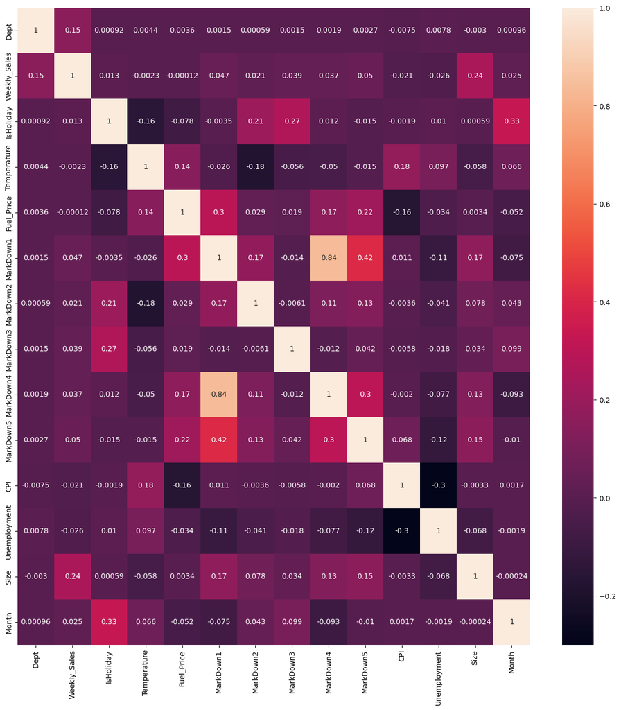

```python
plt.figure(figsize = (16,16))
sns.heatmap(corr_matrix, annot = True)
plt.show()
```

# DATA VISUALIZATION

```python
df
```

|  | Store | Dept | Date | Weekly_Sales | IsHoliday | Temperature | Fuel_Price | MarkDown1 | MarkDown2 | MarkDown3 | MarkDown4 | MarkDown5 | CPI | Unemployment | Type | Size | Month |
| --- | --- | --- | --- | --- | --- | --- | --- | --- | --- | --- | --- | --- | --- | --- | --- | --- | --- |
| 0 | 1 | 1 | 2010-05-02 | 24924.50 | 0 | 42.31 | 2.572 | 0.00 | 0.00 | 0.0 | 0.00 | 0.00 | 211.096358 | 8.106 | A | 151315 | 5 |
| 1 | 1 | 2 | 2010-05-02 | 50605.27 | 0 | 42.31 | 2.572 | 0.00 | 0.00 | 0.0 | 0.00 | 0.00 | 211.096358 | 8.106 | A | 151315 | 5 |
| 2 | 1 | 3 | 2010-05-02 | 13740.12 | 0 | 42.31 | 2.572 | 0.00 | 0.00 | 0.0 | 0.00 | 0.00 | 211.096358 | 8.106 | A | 151315 | 5 |
| 3 | 1 | 4 | 2010-05-02 | 39954.04 | 0 | 42.31 | 2.572 | 0.00 | 0.00 | 0.0 | 0.00 | 0.00 | 211.096358 | 8.106 | A | 151315 | 5 |
| 4 | 1 | 5 | 2010-05-02 | 32229.38 | 0 | 42.31 | 2.572 | 0.00 | 0.00 | 0.0 | 0.00 | 0.00 | 211.096358 | 8.106 | A | 151315 | 5 |
| ... | ... | ... | ... | ... | ... | ... | ... | ... | ... | ... | ... | ... | ... | ... | ... | ... | ... |
| 421565 | 45 | 93 | 2012-10-26 | 2487.80 | 0 | 58.85 | 3.882 | 4018.91 | 58.08 | 100.0 | 211.94 | 858.33 | 192.308899 | 8.667 | B | 118221 | 10 |
| 421566 | 45 | 94 | 2012-10-26 | 5203.31 | 0 | 58.85 | 3.882 | 4018.91 | 58.08 | 100.0 | 211.94 | 858.33 | 192.308899 | 8.667 | B | 118221 | 10 |
| 421567 | 45 | 95 | 2012-10-26 | 56017.47 | 0 | 58.85 | 3.882 | 4018.91 | 58.08 | 100.0 | 211.94 | 858.33 | 192.308899 | 8.667 | B | 118221 | 10 |
| 421568 | 45 | 97 | 2012-10-26 | 6817.48 | 0 | 58.85 | 3.882 | 4018.91 | 58.08 | 100.0 | 211.94 | 858.33 | 192.308899 | 8.667 | B | 118221 | 10 |
| 421569 | 45 | 98 | 2012-10-26 | 1076.80 | 0 | 58.85 | 3.882 | 4018.91 | 58.08 | 100.0 | 211.94 | 858.33 | 192.308899 | 8.667 | B | 118221 | 10 |

421570 rows × 17 columns

```
array([[<Axes: title={'center': 'Store'}>,
        <Axes: title={'center': 'Dept'}>,
        <Axes: title={'center': 'Date'}>,
        <Axes: title={'center': 'Weekly_Sales'}>],
       [<Axes: title={'center': 'IsHoliday'}>,
        <Axes: title={'center': 'Temperature'}>,
        <Axes: title={'center': 'Fuel_Price'}>,
        <Axes: title={'center': 'MarkDown1'}>],
       [<Axes: title={'center': 'MarkDown2'}>,
        <Axes: title={'center': 'MarkDown3'}>,
        <Axes: title={'center': 'MarkDown4'}>,
        <Axes: title={'center': 'MarkDown5'}>],
       [<Axes: title={'center': 'CPI'}>,
        <Axes: title={'center': 'Unemployment'}>,
        <Axes: title={'center': 'Size'}>,
        <Axes: title={'center': 'Month'}>]], dtype=object)
```

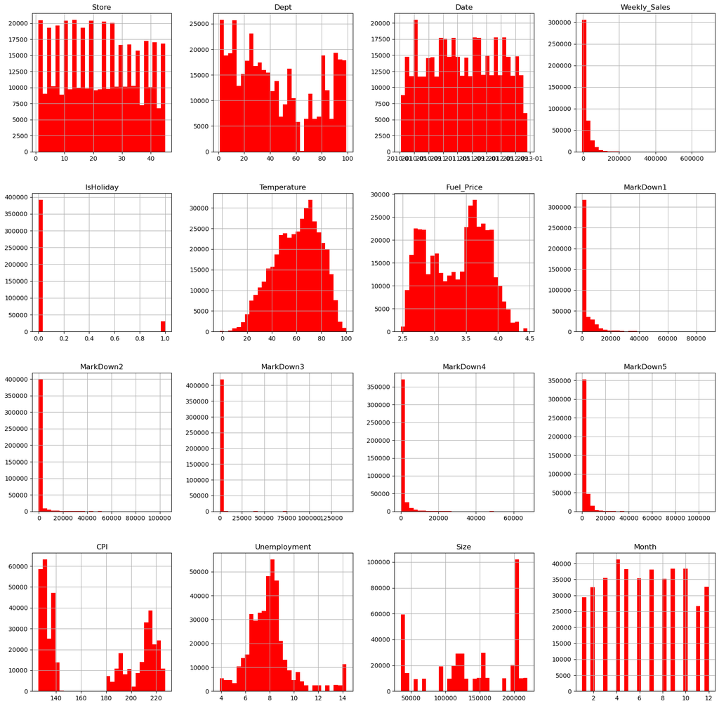

```python
df.hist(bins = 30, figsize = (20,20), color = 'r')
```

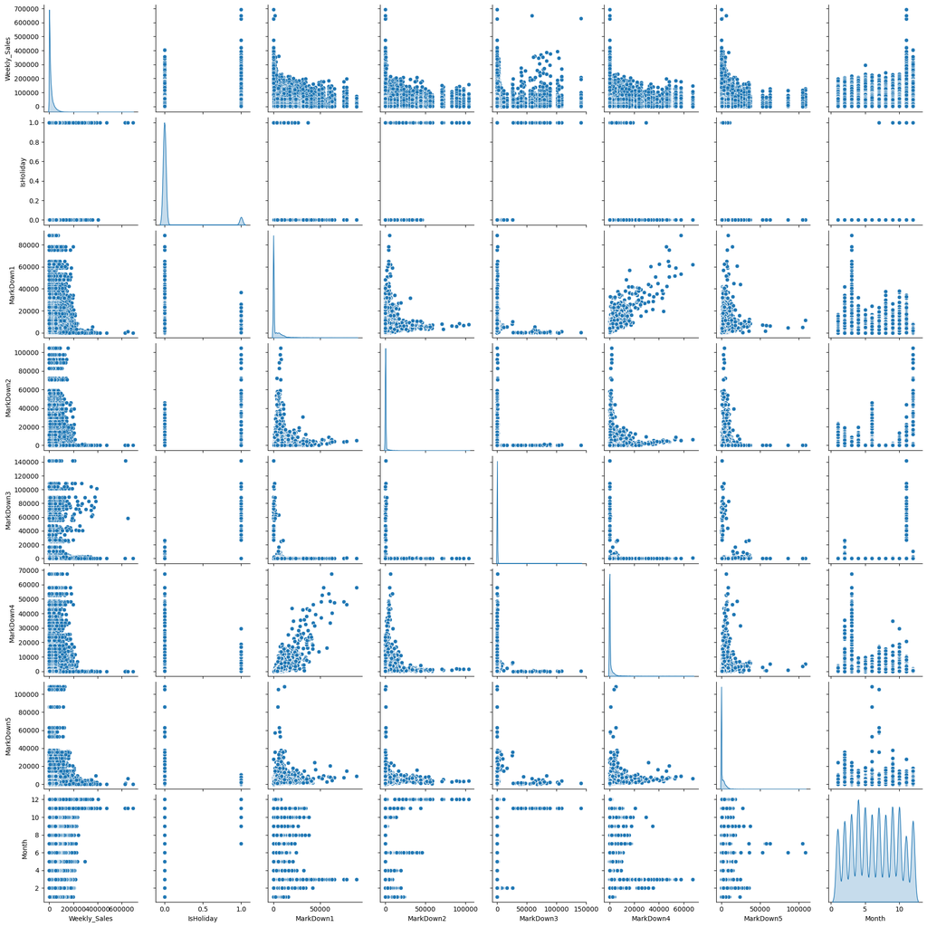

```python
# visualizing the relationship using pairplots
# there is a relationship between markdown #1 and Markdown #4
# holiday and sales
# Weekly sales and markdown #3
sns.pairplot(df[["Weekly_Sales","IsHoliday","MarkDown1","MarkDown2","MarkDown3","MarkDown4","MarkDown5","Type","Month"]], diag_kind = "kde")
```

```python
df_type = df.groupby('Type').mean()
```

```python
df_type
```

| Type | Store | Dept | Date | Weekly_Sales | IsHoliday | Temperature | Fuel_Price | MarkDown1 | MarkDown2 | MarkDown3 | MarkDown4 | MarkDown5 | CPI | Unemployment | Size | Month |
| --- | --- | --- | --- | --- | --- | --- | --- | --- | --- | --- | --- | --- | --- | --- | --- | --- |
| A | 21.736419 | 44.622156 | 2011-06-18 13:48:22.514409984 | 20099.568043 | 0.070471 | 60.531945 | 3.343999 | 3102.403194 | 1083.216159 | 549.644930 | 1325.891281 | 2147.830168 | 174.408895 | 7.791595 | 182231.285486 | 6.480030 |
| B | 18.450417 | 43.112273 | 2011-06-18 22:58:32.430349568 | 12237.075977 | 0.070412 | 57.562951 | 3.382523 | 2553.465968 | 827.500452 | 481.215226 | 1043.927675 | 1324.921913 | 167.176656 | 7.928836 | 101818.735827 | 6.478100 |
| C | 38.942015 | 46.836350 | 2011-06-23 14:53:44.508768256 | 9519.532538 | 0.069582 | 67.554266 | 3.364654 | 138.960203 | 53.274338 | 5.142226 | 5.603993 | 505.826631 | 170.429314 | 8.934350 | 40535.725286 | 6.473085 |

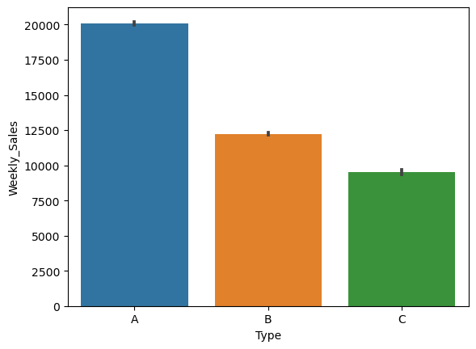

```python
sns.barplot(x = df['Type'], y = df['Weekly_Sales'], data = df)
```

```python
# df_dept = df.drop(columns = ['Store','Type','IsHoliday','Temperature','Fuel_Price','CPI','Unemployment','Size','month'])
numeric_columns = df.select_dtypes(include=['number'])
df_dept = numeric_columns.groupby('Dept').mean()
df_dept
```

| Dept | Store | Weekly_Sales | IsHoliday | Temperature | Fuel_Price | MarkDown1 | MarkDown2 | MarkDown3 | MarkDown4 | MarkDown5 | CPI | Unemployment | Size | Month |
| --- | --- | --- | --- | --- | --- | --- | --- | --- | --- | --- | --- | --- | --- | --- |
| 1 | 23.000000 | 19213.485088 | 0.069930 | 60.663782 | 3.358607 | 2429.019322 | 818.872810 | 429.184037 | 1008.870435 | 1581.806813 | 171.578394 | 7.999151 | 130287.600000 | 6.475524 |
| 2 | 23.000000 | 43607.020113 | 0.069930 | 60.663782 | 3.358607 | 2429.019322 | 818.872810 | 429.184037 | 1008.870435 | 1581.806813 | 171.578394 | 7.999151 | 130287.600000 | 6.475524 |
| 3 | 23.000000 | 11793.698516 | 0.069930 | 60.663782 | 3.358607 | 2429.019322 | 818.872810 | 429.184037 | 1008.870435 | 1581.806813 | 171.578394 | 7.999151 | 130287.600000 | 6.475524 |
| 4 | 23.000000 | 25974.630238 | 0.069930 | 60.663782 | 3.358607 | 2429.019322 | 818.872810 | 429.184037 | 1008.870435 | 1581.806813 | 171.578394 | 7.999151 | 130287.600000 | 6.475524 |
| 5 | 22.757366 | 21365.583515 | 0.069797 | 60.559367 | 3.365397 | 2462.697233 | 830.226332 | 435.134596 | 1022.858240 | 1603.738276 | 171.109374 | 7.978057 | 131530.357964 | 6.479439 |
| ... | ... | ... | ... | ... | ... | ... | ... | ... | ... | ... | ... | ... | ... | ... |
| 95 | 23.000000 | 69824.423080 | 0.069930 | 60.663782 | 3.358607 | 2429.019322 | 818.872810 | 429.184037 | 1008.870435 | 1581.806813 | 171.578394 | 7.999151 | 130287.600000 | 6.475524 |
| 96 | 23.258138 | 15210.942761 | 0.069839 | 61.539285 | 3.359920 | 2362.845647 | 820.762363 | 397.214137 | 999.452087 | 1660.599345 | 171.562686 | 7.849295 | 129282.010507 | 6.482489 |
| 97 | 23.357439 | 14255.576919 | 0.069767 | 60.490781 | 3.362418 | 2463.638764 | 833.096524 | 432.439341 | 1025.957821 | 1591.276367 | 170.445933 | 8.043564 | 130676.377190 | 6.477700 |
| 98 | 24.173920 | 6824.694889 | 0.071967 | 60.115942 | 3.372656 | 2569.994716 | 882.483088 | 467.655716 | 1074.883525 | 1678.390840 | 169.196443 | 8.111493 | 135266.091501 | 6.495716 |
| 99 | 21.438515 | 415.487065 | 0.110209 | 62.813596 | 3.592702 | 7741.403376 | 2164.573063 | 1734.841903 | 3897.476369 | 4526.868643 | 179.263692 | 7.428856 | 186622.052204 | 7.088167 |

81 rows × 14 columns

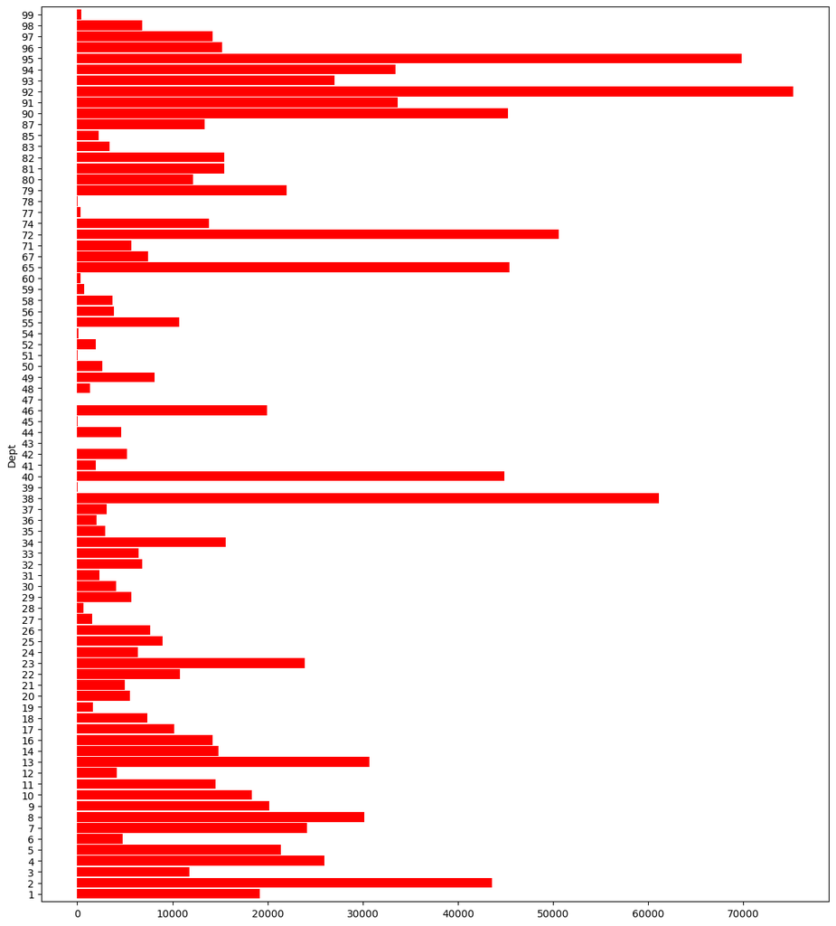

```python
fig = plt.figure(figsize = (14,16))
df_dept['Weekly_Sales'].plot(kind = 'barh', color = 'r', width = 0.9)
```

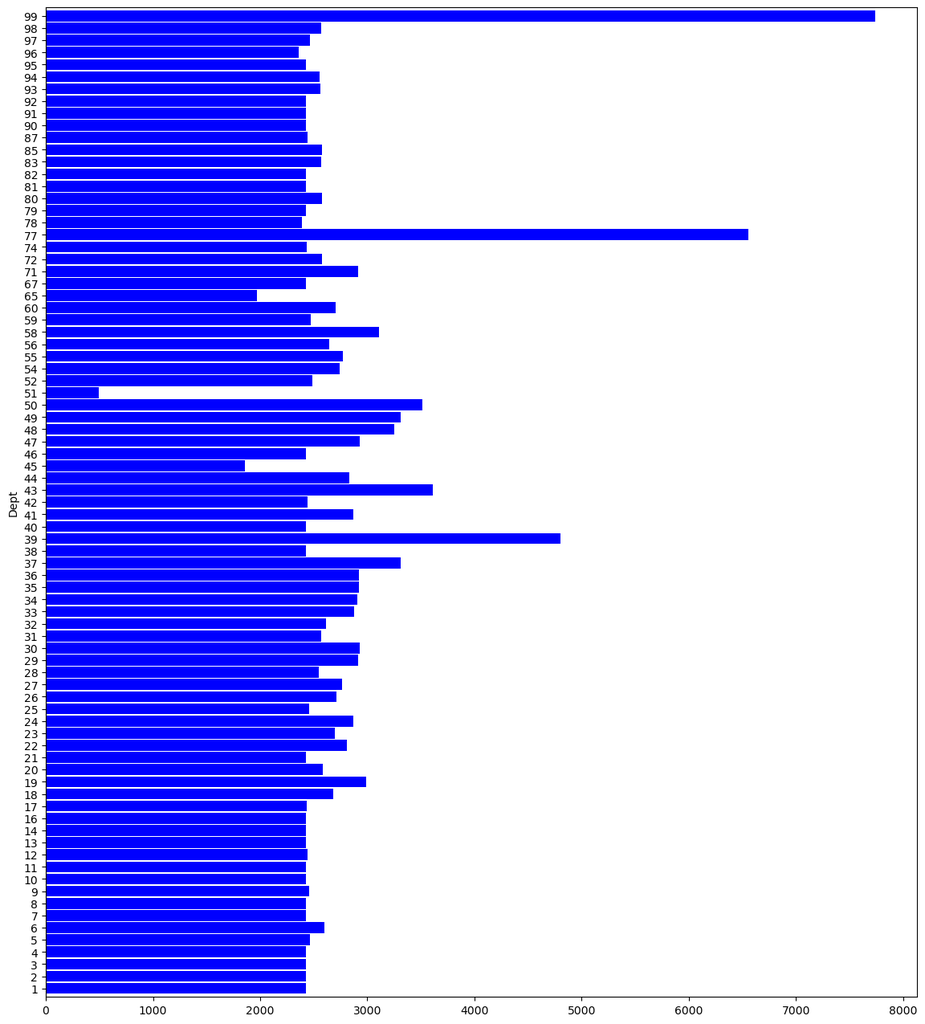

```python
# checking relationship between markdown and sales
fig = plt.figure(figsize = (14,16))
df_dept['MarkDown1'].plot(kind = 'barh', color = 'blue', width = 0.9)
```

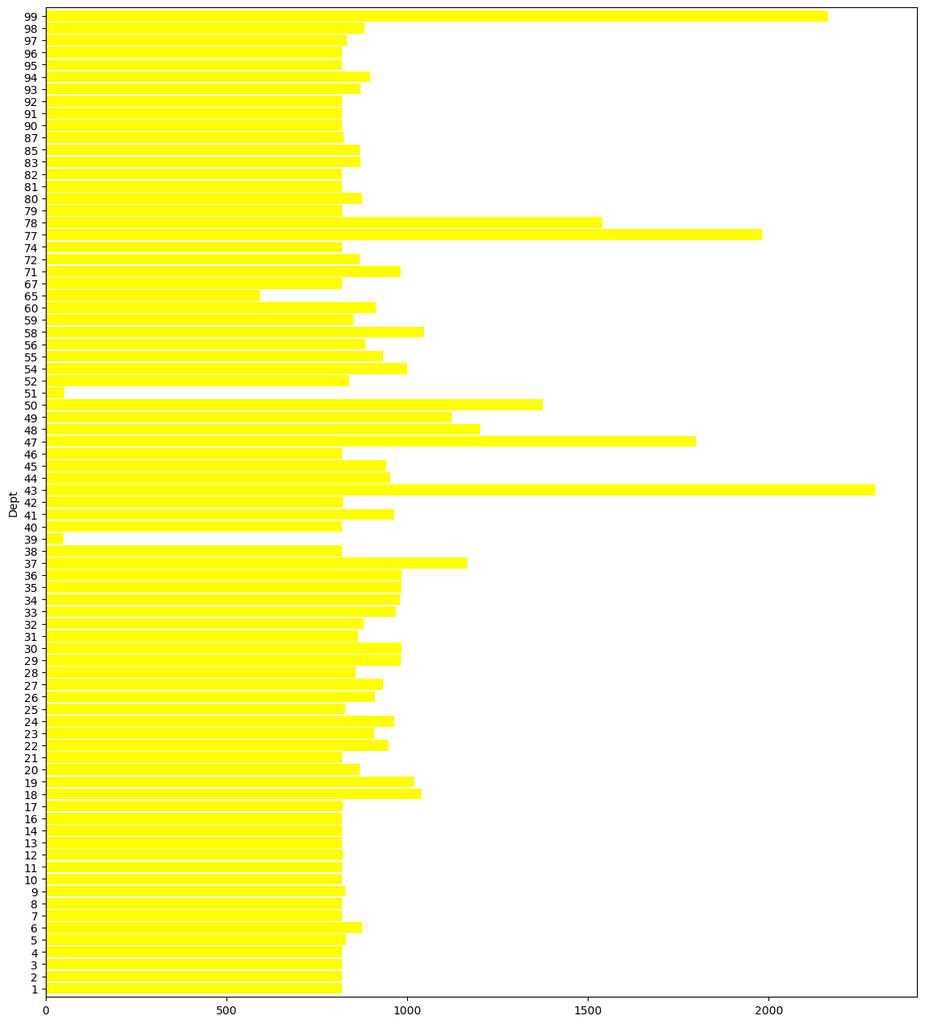

```python
fig = plt.figure(figsize = (14,16))

df_dept['MarkDown2'].plot(kind = 'barh', color = 'yellow', width = 0.9)
```

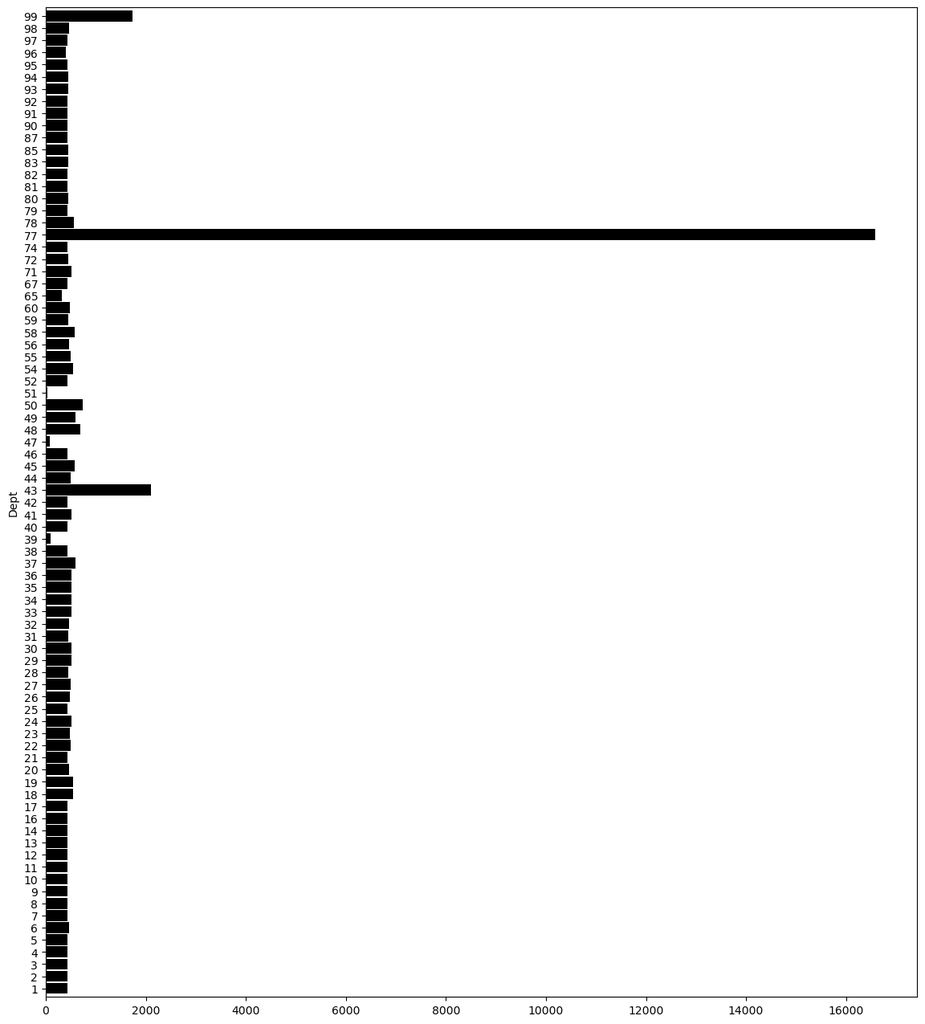

```python
fig = plt.figure(figsize = (14,16))

df_dept['MarkDown3'].plot(kind = 'barh', color = 'black', width = 0.9)
```

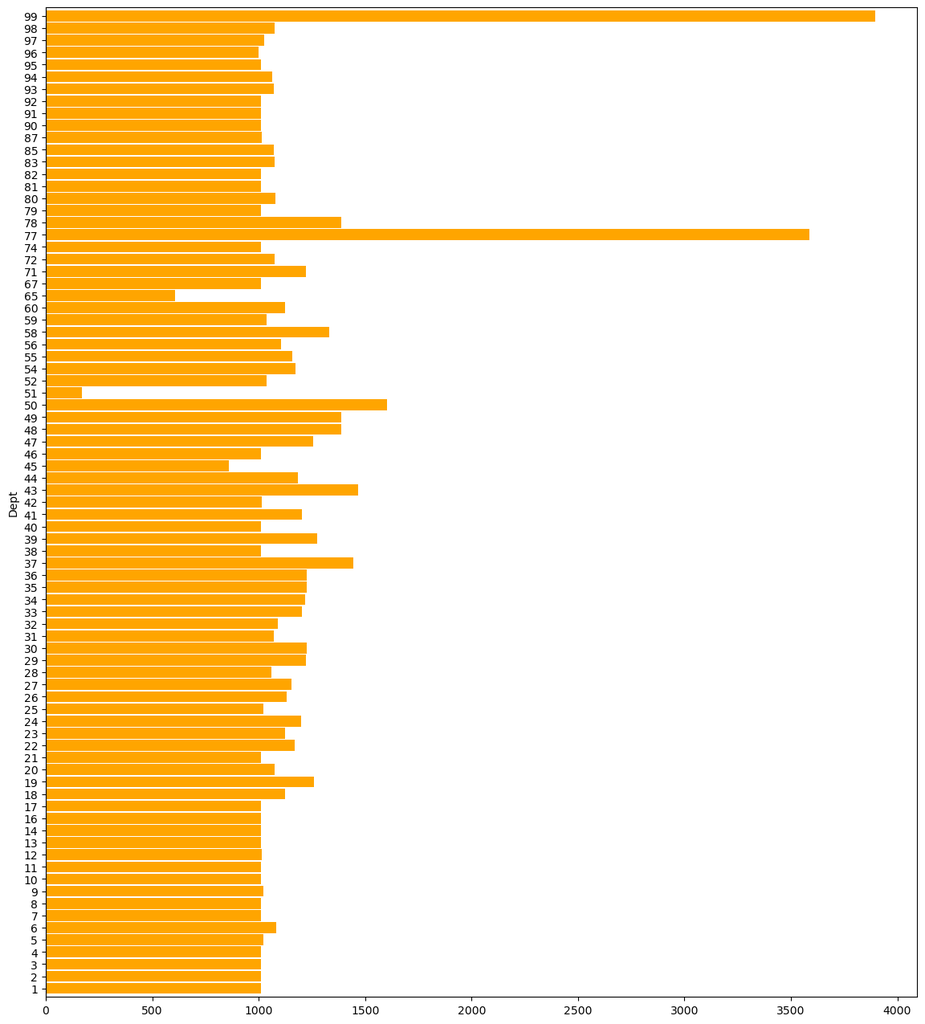

```python
fig = plt.figure(figsize = (14,16))

df_dept['MarkDown4'].plot(kind = 'barh', color = 'orange', width = 0.9)
```

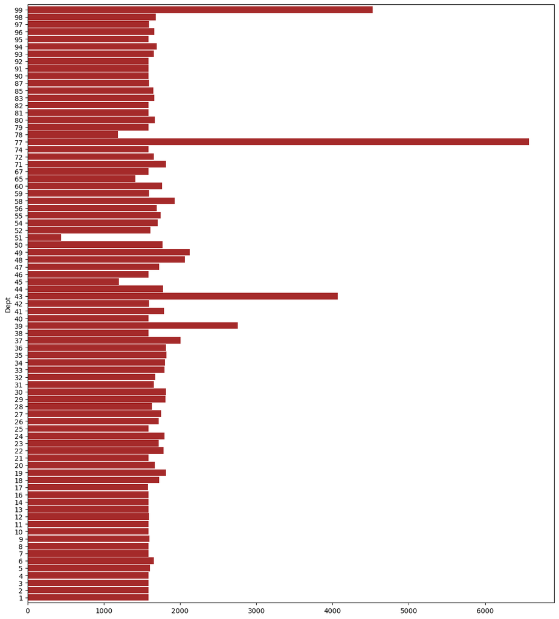

```python
fig = plt.figure(figsize = (14,16))

df_dept['MarkDown5'].plot(kind = 'barh', color = 'brown', width = 0.9)
```

```python
df
```

|  | Store | Dept | Date | Weekly_Sales | IsHoliday | Temperature | Fuel_Price | MarkDown1 | MarkDown2 | MarkDown3 | MarkDown4 | MarkDown5 | CPI | Unemployment | Type | Size | Month |
| --- | --- | --- | --- | --- | --- | --- | --- | --- | --- | --- | --- | --- | --- | --- | --- | --- | --- |
| 0 | 1 | 1 | 2010-05-02 | 24924.50 | 0 | 42.31 | 2.572 | 0.00 | 0.00 | 0.0 | 0.00 | 0.00 | 211.096358 | 8.106 | A | 151315 | 5 |
| 1 | 1 | 2 | 2010-05-02 | 50605.27 | 0 | 42.31 | 2.572 | 0.00 | 0.00 | 0.0 | 0.00 | 0.00 | 211.096358 | 8.106 | A | 151315 | 5 |
| 2 | 1 | 3 | 2010-05-02 | 13740.12 | 0 | 42.31 | 2.572 | 0.00 | 0.00 | 0.0 | 0.00 | 0.00 | 211.096358 | 8.106 | A | 151315 | 5 |
| 3 | 1 | 4 | 2010-05-02 | 39954.04 | 0 | 42.31 | 2.572 | 0.00 | 0.00 | 0.0 | 0.00 | 0.00 | 211.096358 | 8.106 | A | 151315 | 5 |
| 4 | 1 | 5 | 2010-05-02 | 32229.38 | 0 | 42.31 | 2.572 | 0.00 | 0.00 | 0.0 | 0.00 | 0.00 | 211.096358 | 8.106 | A | 151315 | 5 |
| ... | ... | ... | ... | ... | ... | ... | ... | ... | ... | ... | ... | ... | ... | ... | ... | ... | ... |
| 421565 | 45 | 93 | 2012-10-26 | 2487.80 | 0 | 58.85 | 3.882 | 4018.91 | 58.08 | 100.0 | 211.94 | 858.33 | 192.308899 | 8.667 | B | 118221 | 10 |
| 421566 | 45 | 94 | 2012-10-26 | 5203.31 | 0 | 58.85 | 3.882 | 4018.91 | 58.08 | 100.0 | 211.94 | 858.33 | 192.308899 | 8.667 | B | 118221 | 10 |
| 421567 | 45 | 95 | 2012-10-26 | 56017.47 | 0 | 58.85 | 3.882 | 4018.91 | 58.08 | 100.0 | 211.94 | 858.33 | 192.308899 | 8.667 | B | 118221 | 10 |
| 421568 | 45 | 97 | 2012-10-26 | 6817.48 | 0 | 58.85 | 3.882 | 4018.91 | 58.08 | 100.0 | 211.94 | 858.33 | 192.308899 | 8.667 | B | 118221 | 10 |
| 421569 | 45 | 98 | 2012-10-26 | 1076.80 | 0 | 58.85 | 3.882 | 4018.91 | 58.08 | 100.0 | 211.94 | 858.33 | 192.308899 | 8.667 | B | 118221 | 10 |

421570 rows × 17 columns

## CONCLUSIONS FROM THE DATA VISUALIZATION

```python
# Sort by weekly sales
df_dept_sale = df_dept.sort_values(by = ['Weekly_Sales'], ascending = True)
df_dept_sale['Weekly_Sales'][:30]
```

```
Dept
47      -7.682554
43       1.193333
78       7.296638
39      11.123750
51      21.931729
45      23.211586
54     108.305985
77     328.961800
60     347.370229
99     415.487065
28     618.085116
59     694.463564
48    1344.893576
27    1583.437727
```

[output cut: 17 more lines]

# DATA PREPROCESSING

```python
df
```

|  | Store | Dept | Date | Weekly_Sales | IsHoliday | Temperature | Fuel_Price | MarkDown1 | MarkDown2 | MarkDown3 | MarkDown4 | MarkDown5 | CPI | Unemployment | Type | Size | Month |
| --- | --- | --- | --- | --- | --- | --- | --- | --- | --- | --- | --- | --- | --- | --- | --- | --- | --- |
| 0 | 1 | 1 | 2010-05-02 | 24924.50 | 0 | 42.31 | 2.572 | 0.00 | 0.00 | 0.0 | 0.00 | 0.00 | 211.096358 | 8.106 | A | 151315 | 5 |
| 1 | 1 | 2 | 2010-05-02 | 50605.27 | 0 | 42.31 | 2.572 | 0.00 | 0.00 | 0.0 | 0.00 | 0.00 | 211.096358 | 8.106 | A | 151315 | 5 |
| 2 | 1 | 3 | 2010-05-02 | 13740.12 | 0 | 42.31 | 2.572 | 0.00 | 0.00 | 0.0 | 0.00 | 0.00 | 211.096358 | 8.106 | A | 151315 | 5 |
| 3 | 1 | 4 | 2010-05-02 | 39954.04 | 0 | 42.31 | 2.572 | 0.00 | 0.00 | 0.0 | 0.00 | 0.00 | 211.096358 | 8.106 | A | 151315 | 5 |
| 4 | 1 | 5 | 2010-05-02 | 32229.38 | 0 | 42.31 | 2.572 | 0.00 | 0.00 | 0.0 | 0.00 | 0.00 | 211.096358 | 8.106 | A | 151315 | 5 |
| ... | ... | ... | ... | ... | ... | ... | ... | ... | ... | ... | ... | ... | ... | ... | ... | ... | ... |
| 421565 | 45 | 93 | 2012-10-26 | 2487.80 | 0 | 58.85 | 3.882 | 4018.91 | 58.08 | 100.0 | 211.94 | 858.33 | 192.308899 | 8.667 | B | 118221 | 10 |
| 421566 | 45 | 94 | 2012-10-26 | 5203.31 | 0 | 58.85 | 3.882 | 4018.91 | 58.08 | 100.0 | 211.94 | 858.33 | 192.308899 | 8.667 | B | 118221 | 10 |
| 421567 | 45 | 95 | 2012-10-26 | 56017.47 | 0 | 58.85 | 3.882 | 4018.91 | 58.08 | 100.0 | 211.94 | 858.33 | 192.308899 | 8.667 | B | 118221 | 10 |
| 421568 | 45 | 97 | 2012-10-26 | 6817.48 | 0 | 58.85 | 3.882 | 4018.91 | 58.08 | 100.0 | 211.94 | 858.33 | 192.308899 | 8.667 | B | 118221 | 10 |
| 421569 | 45 | 98 | 2012-10-26 | 1076.80 | 0 | 58.85 | 3.882 | 4018.91 | 58.08 | 100.0 | 211.94 | 858.33 | 192.308899 | 8.667 | B | 118221 | 10 |

421570 rows × 17 columns

```python
df['Dept'].dtype
```

```
dtype('int64')
```

```python
# Drop the date
df_target = df['Weekly_Sales']
df_final = df.drop(columns = ['Weekly_Sales', 'Date'])
```

```python
df_final
```

|  | Store | Dept | IsHoliday | Temperature | Fuel_Price | MarkDown1 | MarkDown2 | MarkDown3 | MarkDown4 | MarkDown5 | CPI | Unemployment | Type | Size | Month |
| --- | --- | --- | --- | --- | --- | --- | --- | --- | --- | --- | --- | --- | --- | --- | --- |
| 0 | 1 | 1 | 0 | 42.31 | 2.572 | 0.00 | 0.00 | 0.0 | 0.00 | 0.00 | 211.096358 | 8.106 | A | 151315 | 5 |
| 1 | 1 | 2 | 0 | 42.31 | 2.572 | 0.00 | 0.00 | 0.0 | 0.00 | 0.00 | 211.096358 | 8.106 | A | 151315 | 5 |
| 2 | 1 | 3 | 0 | 42.31 | 2.572 | 0.00 | 0.00 | 0.0 | 0.00 | 0.00 | 211.096358 | 8.106 | A | 151315 | 5 |
| 3 | 1 | 4 | 0 | 42.31 | 2.572 | 0.00 | 0.00 | 0.0 | 0.00 | 0.00 | 211.096358 | 8.106 | A | 151315 | 5 |
| 4 | 1 | 5 | 0 | 42.31 | 2.572 | 0.00 | 0.00 | 0.0 | 0.00 | 0.00 | 211.096358 | 8.106 | A | 151315 | 5 |
| ... | ... | ... | ... | ... | ... | ... | ... | ... | ... | ... | ... | ... | ... | ... | ... |
| 421565 | 45 | 93 | 0 | 58.85 | 3.882 | 4018.91 | 58.08 | 100.0 | 211.94 | 858.33 | 192.308899 | 8.667 | B | 118221 | 10 |
| 421566 | 45 | 94 | 0 | 58.85 | 3.882 | 4018.91 | 58.08 | 100.0 | 211.94 | 858.33 | 192.308899 | 8.667 | B | 118221 | 10 |
| 421567 | 45 | 95 | 0 | 58.85 | 3.882 | 4018.91 | 58.08 | 100.0 | 211.94 | 858.33 | 192.308899 | 8.667 | B | 118221 | 10 |
| 421568 | 45 | 97 | 0 | 58.85 | 3.882 | 4018.91 | 58.08 | 100.0 | 211.94 | 858.33 | 192.308899 | 8.667 | B | 118221 | 10 |
| 421569 | 45 | 98 | 0 | 58.85 | 3.882 | 4018.91 | 58.08 | 100.0 | 211.94 | 858.33 | 192.308899 | 8.667 | B | 118221 | 10 |

421570 rows × 15 columns

```python
df_final = pd.get_dummies(df_final, columns = ['Type', 'Store', 'Dept'], drop_first = True)
```

```python
df_final
```

|  | IsHoliday | Temperature | Fuel_Price | MarkDown1 | MarkDown2 | MarkDown3 | MarkDown4 | MarkDown5 | CPI | Unemployment | ... | Dept_90 | Dept_91 | Dept_92 | Dept_93 | Dept_94 | Dept_95 | Dept_96 | Dept_97 | Dept_98 | Dept_99 |
| --- | --- | --- | --- | --- | --- | --- | --- | --- | --- | --- | --- | --- | --- | --- | --- | --- | --- | --- | --- | --- | --- |
| 0 | 0 | 42.31 | 2.572 | 0.00 | 0.00 | 0.0 | 0.00 | 0.00 | 211.096358 | 8.106 | ... | False | False | False | False | False | False | False | False | False | False |
| 1 | 0 | 42.31 | 2.572 | 0.00 | 0.00 | 0.0 | 0.00 | 0.00 | 211.096358 | 8.106 | ... | False | False | False | False | False | False | False | False | False | False |
| 2 | 0 | 42.31 | 2.572 | 0.00 | 0.00 | 0.0 | 0.00 | 0.00 | 211.096358 | 8.106 | ... | False | False | False | False | False | False | False | False | False | False |
| 3 | 0 | 42.31 | 2.572 | 0.00 | 0.00 | 0.0 | 0.00 | 0.00 | 211.096358 | 8.106 | ... | False | False | False | False | False | False | False | False | False | False |
| 4 | 0 | 42.31 | 2.572 | 0.00 | 0.00 | 0.0 | 0.00 | 0.00 | 211.096358 | 8.106 | ... | False | False | False | False | False | False | False | False | False | False |
| ... | ... | ... | ... | ... | ... | ... | ... | ... | ... | ... | ... | ... | ... | ... | ... | ... | ... | ... | ... | ... | ... |
| 421565 | 0 | 58.85 | 3.882 | 4018.91 | 58.08 | 100.0 | 211.94 | 858.33 | 192.308899 | 8.667 | ... | False | False | False | True | False | False | False | False | False | False |
| 421566 | 0 | 58.85 | 3.882 | 4018.91 | 58.08 | 100.0 | 211.94 | 858.33 | 192.308899 | 8.667 | ... | False | False | False | False | True | False | False | False | False | False |
| 421567 | 0 | 58.85 | 3.882 | 4018.91 | 58.08 | 100.0 | 211.94 | 858.33 | 192.308899 | 8.667 | ... | False | False | False | False | False | True | False | False | False | False |
| 421568 | 0 | 58.85 | 3.882 | 4018.91 | 58.08 | 100.0 | 211.94 | 858.33 | 192.308899 | 8.667 | ... | False | False | False | False | False | False | False | True | False | False |
| 421569 | 0 | 58.85 | 3.882 | 4018.91 | 58.08 | 100.0 | 211.94 | 858.33 | 192.308899 | 8.667 | ... | False | False | False | False | False | False | False | False | True | False |

421570 rows × 138 columns

```python
df_final.shape
```

```
(421570, 138)
```

```python
df_target.shape
```

```
(421570,)
```

```python
df_final
# df_final['Dept_91'].dtype
```

|  | IsHoliday | Temperature | Fuel_Price | MarkDown1 | MarkDown2 | MarkDown3 | MarkDown4 | MarkDown5 | CPI | Unemployment | ... | Dept_90 | Dept_91 | Dept_92 | Dept_93 | Dept_94 | Dept_95 | Dept_96 | Dept_97 | Dept_98 | Dept_99 |
| --- | --- | --- | --- | --- | --- | --- | --- | --- | --- | --- | --- | --- | --- | --- | --- | --- | --- | --- | --- | --- | --- |
| 0 | 0 | 42.31 | 2.572 | 0.00 | 0.00 | 0.0 | 0.00 | 0.00 | 211.096358 | 8.106 | ... | False | False | False | False | False | False | False | False | False | False |
| 1 | 0 | 42.31 | 2.572 | 0.00 | 0.00 | 0.0 | 0.00 | 0.00 | 211.096358 | 8.106 | ... | False | False | False | False | False | False | False | False | False | False |
| 2 | 0 | 42.31 | 2.572 | 0.00 | 0.00 | 0.0 | 0.00 | 0.00 | 211.096358 | 8.106 | ... | False | False | False | False | False | False | False | False | False | False |
| 3 | 0 | 42.31 | 2.572 | 0.00 | 0.00 | 0.0 | 0.00 | 0.00 | 211.096358 | 8.106 | ... | False | False | False | False | False | False | False | False | False | False |
| 4 | 0 | 42.31 | 2.572 | 0.00 | 0.00 | 0.0 | 0.00 | 0.00 | 211.096358 | 8.106 | ... | False | False | False | False | False | False | False | False | False | False |
| ... | ... | ... | ... | ... | ... | ... | ... | ... | ... | ... | ... | ... | ... | ... | ... | ... | ... | ... | ... | ... | ... |
| 421565 | 0 | 58.85 | 3.882 | 4018.91 | 58.08 | 100.0 | 211.94 | 858.33 | 192.308899 | 8.667 | ... | False | False | False | True | False | False | False | False | False | False |
| 421566 | 0 | 58.85 | 3.882 | 4018.91 | 58.08 | 100.0 | 211.94 | 858.33 | 192.308899 | 8.667 | ... | False | False | False | False | True | False | False | False | False | False |
| 421567 | 0 | 58.85 | 3.882 | 4018.91 | 58.08 | 100.0 | 211.94 | 858.33 | 192.308899 | 8.667 | ... | False | False | False | False | False | True | False | False | False | False |
| 421568 | 0 | 58.85 | 3.882 | 4018.91 | 58.08 | 100.0 | 211.94 | 858.33 | 192.308899 | 8.667 | ... | False | False | False | False | False | False | False | True | False | False |
| 421569 | 0 | 58.85 | 3.882 | 4018.91 | 58.08 | 100.0 | 211.94 | 858.33 | 192.308899 | 8.667 | ... | False | False | False | False | False | False | False | False | True | False |

421570 rows × 138 columns

```python
X = np.array(df_final).astype('float32')
y = np.array(df_target).astype('float32')
```

```python
# reshaping the array from (421570,) to (421570, 1)
y = y.reshape(-1,1)
y.shape
```

```
(421570, 1)
```

```python
# scaling the data before feeding the model
# from sklearn.preprocessing import StandardScaler, MinMaxScaler

# scaler_x = StandardScaler()
# X = scaler_x.fit_transform(X)

# scaler_y = StandardScaler()
# y = scaler_y.fit_transform(y)
```

```python
# spliting the data in to test and train sets
from sklearn.model_selection import train_test_split

X_train, X_test, y_train, y_test = train_test_split(X, y, test_size = 0.15)
X_test, X_val, y_test, y_val = train_test_split(X_test, y_test, test_size = 0.5)
```

```python
X_train
```

```
array([[ 0.   , 14.48 ,  2.788, ...,  0.   ,  0.   ,  0.   ],
       [ 0.   , 68.28 ,  3.623, ...,  0.   ,  0.   ,  0.   ],
       [ 0.   , 36.46 ,  3.261, ...,  0.   ,  0.   ,  0.   ],
       ...,
       [ 0.   , 66.59 ,  4.169, ...,  0.   ,  0.   ,  0.   ],
       [ 0.   , 21.33 ,  2.788, ...,  0.   ,  0.   ,  0.   ],
       [ 1.   , 47.87 ,  2.946, ...,  0.   ,  0.   ,  0.   ]],
      dtype=float32)
```

# TRAINING XGBOOST REGRESSOR IN LOCAL MODE

```python
!pip install xgboost
```

```
  Obtaining dependency information for xgboost from https://files.pythonhosted.org/packages/c1/cf/a662bc8f40588d54663edfe12980946670490bff0b6e793c7896a4fe36df/xgboost-2.0.0-py3-none-manylinux2014_x86_64.whl.metadata
Downloading xgboost-2.0.0-py3-none-manylinux2014_x86_64.whl (297.1 MB)
   ━━━━━━━━━━━━━━━━━━━━━━━━━━━━━━━━━━━━━━━━ 297.1/297.1 MB 3.6 MB/s eta 0:00:00:00:0100:01
```

```python
# Train an XGBoost regressor model

import xgboost as xgb


model = xgb.XGBRegressor(objective ='reg:squarederror', learning_rate = 0.1, max_depth = 5, n_estimators = 100)

model.fit(X_train, y_train)
```

```
XGBRegressor(base_score=None, booster=None, callbacks=None,
             colsample_bylevel=None, colsample_bynode=None,
             colsample_bytree=None, device=None, early_stopping_rounds=None,
             enable_categorical=False, eval_metric=None, feature_types=None,
             gamma=None, grow_policy=None, importance_type=None,
             interaction_constraints=None, learning_rate=0.1, max_bin=None,
             max_cat_threshold=None, max_cat_to_onehot=None,
             max_delta_step=None, max_depth=5, max_leaves=None,
             min_child_weight=None, missing=nan, monotone_constraints=None,
             multi_strategy=None, n_estimators=100, n_jobs=None,
             num_parallel_tree=None, random_state=None, ...)
```

```python
# predict the score of the trained model using the testing dataset

result = model.score(X_test, y_test)

print("Accuracy : {}".format(result))
```

```
Accuracy : 0.817197891650735
```

```python
# make predictions on the test data

y_predict = model.predict(X_test)
```

```python
from sklearn.metrics import r2_score, mean_squared_error, mean_absolute_error
from math import sqrt
k = X_test.shape[1]
n = len(X_test)
RMSE = float(format(np.sqrt(mean_squared_error(y_test, y_predict)),'.3f'))
MSE = mean_squared_error(y_test, y_predict)
MAE = mean_absolute_error(y_test, y_predict)
r2 = r2_score(y_test, y_predict)
adj_r2 = 1-(1-r2)*(n-1)/(n-k-1)

print('RMSE =',RMSE, '\nMSE =',MSE, '\nMAE =',MAE, '\nR2 =', r2, '\nAdjusted R2 =', adj_r2)
```

```
RMSE = 9598.279
MSE = 92126960.0
MAE = 6432.6113
R2 = 0.817197891650735
Adjusted R2 = 0.8163965100645283
```

# TRAIN XGBOOST USING AWS SAGEMAKER

```python
# Convert the array into dataframe in a way that target variable is set as the first column and followed by feature columns
# This is because sagemaker built-in algorithm expects the data in this format.

train_data = pd.DataFrame({'Target': y_train[:,0]})
for i in range(X_train.shape[1]):
    train_data[i] = X_train[:,i]
```

[output not shown]

[output cut: 52 more lines]

```python
train_data.head()
```

|  | Target | 0 | 1 | 2 | 3 | 4 | 5 | 6 | 7 | 8 | ... | 128 | 129 | 130 | 131 | 132 | 133 | 134 | 135 | 136 | 137 |
| --- | --- | --- | --- | --- | --- | --- | --- | --- | --- | --- | --- | --- | --- | --- | --- | --- | --- | --- | --- | --- | --- |
| 0 | 6700.479980 | 0.0 | 14.480000 | 2.788 | 0.000000 | 0.000000 | 0.00 | 0.000000 | 0.000000 | 131.527908 | ... | 0.0 | 0.0 | 0.0 | 0.0 | 0.0 | 0.0 | 0.0 | 0.0 | 0.0 | 0.0 |
| 1 | 4752.750000 | 0.0 | 68.279999 | 3.623 | 0.000000 | 0.000000 | 0.00 | 0.000000 | 0.000000 | 129.606064 | ... | 0.0 | 0.0 | 0.0 | 0.0 | 0.0 | 0.0 | 0.0 | 0.0 | 0.0 | 0.0 |
| 2 | 3350.169922 | 0.0 | 36.459999 | 3.261 | 6725.290039 | 12764.990234 | 15.98 | 299.730011 | 3851.689941 | 223.424255 | ... | 0.0 | 0.0 | 0.0 | 0.0 | 0.0 | 0.0 | 0.0 | 0.0 | 0.0 | 0.0 |
| 3 | 12487.440430 | 0.0 | 62.060001 | 2.992 | 0.000000 | 0.000000 | 0.00 | 0.000000 | 0.000000 | 131.940811 | ... | 0.0 | 0.0 | 0.0 | 0.0 | 0.0 | 0.0 | 0.0 | 0.0 | 0.0 | 0.0 |
| 4 | 17425.750000 | 0.0 | 60.380001 | 4.066 | 0.000000 | 0.000000 | 0.00 | 0.000000 | 0.000000 | 186.071930 | ... | 0.0 | 0.0 | 0.0 | 0.0 | 0.0 | 0.0 | 0.0 | 0.0 | 0.0 | 0.0 |

5 rows × 139 columns

```python
val_data = pd.DataFrame({'Target':y_val[:,0]})
for i in range(X_val.shape[1]):
    val_data[i] = X_val[:,i]
```

[output not shown]

[output cut: 52 more lines]

```python
val_data.head()
```

|  | Target | 0 | 1 | 2 | 3 | 4 | 5 | 6 | 7 | 8 | ... | 128 | 129 | 130 | 131 | 132 | 133 | 134 | 135 | 136 | 137 |
| --- | --- | --- | --- | --- | --- | --- | --- | --- | --- | --- | --- | --- | --- | --- | --- | --- | --- | --- | --- | --- | --- |
| 0 | 5107.509766 | 0.0 | 57.160000 | 2.886 | 0.0 | 0.0 | 0.0 | 0.0 | 0.0 | 214.701782 | ... | 0.0 | 0.0 | 0.0 | 0.0 | 0.0 | 0.0 | 0.0 | 0.0 | 0.0 | 0.0 |
| 1 | 74557.250000 | 0.0 | 70.900002 | 2.725 | 0.0 | 0.0 | 0.0 | 0.0 | 0.0 | 209.170776 | ... | 0.0 | 0.0 | 0.0 | 0.0 | 1.0 | 0.0 | 0.0 | 0.0 | 0.0 | 0.0 |
| 2 | 2631.409912 | 0.0 | 47.410000 | 3.567 | 0.0 | 0.0 | 0.0 | 0.0 | 0.0 | 129.793671 | ... | 0.0 | 0.0 | 0.0 | 0.0 | 0.0 | 0.0 | 0.0 | 0.0 | 0.0 | 0.0 |
| 3 | 6683.109863 | 0.0 | 36.779999 | 2.817 | 0.0 | 0.0 | 0.0 | 0.0 | 0.0 | 126.793404 | ... | 0.0 | 0.0 | 0.0 | 0.0 | 0.0 | 0.0 | 0.0 | 0.0 | 0.0 | 0.0 |
| 4 | 6921.649902 | 0.0 | 48.889999 | 2.625 | 0.0 | 0.0 | 0.0 | 0.0 | 0.0 | 211.907166 | ... | 0.0 | 0.0 | 0.0 | 0.0 | 0.0 | 0.0 | 0.0 | 0.0 | 0.0 | 0.0 |

5 rows × 139 columns

```python
val_data.shape
```

```
(31618, 139)
```

```python
# save train_data and validation_data as csv files.

train_data.to_csv('train.csv', header = False, index = False)
val_data.to_csv('validation.csv', header = False, index = False)
```

```python
# Boto3 is the Amazon Web Services (AWS) Software Development Kit (SDK) for Python
# Boto3 allows Python developer to write software that makes use of services like Amazon S3 and Amazon EC2

import sagemaker
import boto3
from sagemaker import Session

# create a Sagemaker session
sagemaker_session = sagemaker.Session()
bucket = Session().default_bucket()
prefix = 'XGBoost-Regressor'
key = 'XGBoost-Regressor'
#Roles give learning and hosting access to the data
#This is specified while opening the sagemakers instance in "Create an IAM role"
role = sagemaker.get_execution_role()
```

```python
print(role)
```

```
arn:aws:iam::058058168096:role/service-role/AmazonSageMaker-ExecutionRole-20230906T182286
```

```python
# read the data from csv file and then upload the data to s3 bucket
import os
with open('train.csv','rb') as f:
    # The following code uploads the data into S3 bucket to be accessed later for training
    boto3.Session().resource('s3').Bucket(bucket).Object(os.path.join(prefix, 'train', key)).upload_fileobj(f)

# print out the training data location in s3
s3_train_data = 's3://{}/{}/train/{}'.format(bucket, prefix, key)
print('uploaded training data location: {}'.format(s3_train_data))
```

```
uploaded training data location: s3://sagemaker-us-east-1-058058168096/XGBoost-Regressor/train/XGBoost-Regressor
```

```python
# read the data from csv file and then upload the data to s3 bucket

with open('validation.csv','rb') as f:
    # The following code uploads the data into S3 bucket to be accessed later for training

    boto3.Session().resource('s3').Bucket(bucket).Object(os.path.join(prefix, 'validation', key)).upload_fileobj(f)
# print out the validation data location in s3
s3_validation_data = 's3://{}/{}/validation/{}'.format(bucket, prefix, key)
print('uploaded validation data location: {}'.format(s3_validation_data))
```

```
uploaded validation data location: s3://sagemaker-us-east-1-058058168096/XGBoost-Regressor/validation/XGBoost-Regressor
```

```python
# creates output placeholder in S3 bucket to store the output

output_location = 's3://{}/{}/output'.format(bucket, prefix)
print('training artifacts will be uploaded to: {}'.format(output_location))
```

```
training artifacts will be uploaded to: s3://sagemaker-us-east-1-058058168096/XGBoost-Regressor/output
```

```python
# This code is used to get the training container of sagemaker built-in algorithms

# obtain a reference to the XGBoost container image
# all regression models are named estimators

from sagemaker.amazon.amazon_estimator import get_image_uri

container = get_image_uri(boto3.Session().region_name, 'xgboost','0.90-2')
```

```
The method get_image_uri has been renamed in sagemaker>=2.
See: https://sagemaker.readthedocs.io/en/stable/v2.html for details.
```

```python
# Specify the type of instance that we would like to use for training
# output path and sagemaker session into the Estimator.
# specify how many instances we would like to use for training

# XGBoost works by combining an ensemble of weak models to generate accurate/robust results.
# The weak models are randomized to avoid overfitting

# num_round: The number of rounds to run the training.


# Alpha: L1 regularization term on weights. Increasing this value makes models more conservative.

# colsample_by_tree: fraction of features that will be used to train each tree.

# eta: Step size shrinkage used in updates to prevent overfitting.
# After each boosting step, eta parameter shrinks the feature weights to make the boosting process more conservative.


Xgboost_regressor1 = sagemaker.estimator.Estimator(container,
                                       role,
                                       train_instance_count = 1,
                                       train_instance_type = 'ml.m5.2xlarge',
                                       output_path = output_location,
                                       sagemaker_session = sagemaker_session)

# tune the hyper-parameters to improve the performance of the model

Xgboost_regressor1.set_hyperparameters(max_depth = 10,
                           objective = 'reg:linear',
                           colsample_bytree = 0.3,
                           alpha = 10,
                           eta = 0.1,
                           num_round = 100
                           )
```

```
train_instance_count has been renamed in sagemaker>=2.
See: https://sagemaker.readthedocs.io/en/stable/v2.html for details.
train_instance_type has been renamed in sagemaker>=2.
See: https://sagemaker.readthedocs.io/en/stable/v2.html for details.
```

```python
# Creating "train", "validation" channels to feed in the model
# Source: https://docs.aws.amazon.com/sagemaker/latest/dg/sagemaker-algo-docker-registry-paths.html

train_input = sagemaker.session.s3_input(s3_data = s3_train_data, content_type='csv',s3_data_type = 'S3Prefix')
valid_input = sagemaker.session.s3_input(s3_data = s3_validation_data, content_type='csv',s3_data_type = 'S3Prefix')


data_channels = {'train': train_input,'validation': valid_input}


Xgboost_regressor1.fit(data_channels)
```

```
The class sagemaker.session.s3_input has been renamed in sagemaker>=2.
See: https://sagemaker.readthedocs.io/en/stable/v2.html for details.
The class sagemaker.session.s3_input has been renamed in sagemaker>=2.
See: https://sagemaker.readthedocs.io/en/stable/v2.html for details.
INFO:sagemaker:Creating training-job with name: sagemaker-xgboost-2023-09-12-10-00-17-538
```

```
2023-09-12 10:00:17 Starting - Starting the training job...
2023-09-12 10:00:34 Starting - Preparing the instances for training............
2023-09-12 10:02:23 Downloading - Downloading input data...
2023-09-12 10:03:13 Training - Training image download completed. Training in progress....INFO:sagemaker-containers:Imported framework sagemaker_xgboost_container.training
INFO:sagemaker-containers:Failed to parse hyperparameter objective value reg:linear to Json.
Returning the value itself
INFO:sagemaker-containers:No GPUs detected (normal if no gpus installed)
INFO:sagemaker_xgboost_container.training:Running XGBoost Sagemaker in algorithm mode
INFO:root:Determined delimiter of CSV input is ','
INFO:root:Determined delimiter of CSV input is ','
INFO:root:Determined delimiter of CSV input is ','
[10:03:35] 358334x138 matrix with 49450092 entries loaded from /opt/ml/input/data/train?format=csv&label_column=0&delimiter=,
INFO:root:Determined delimiter of CSV input is ','
[10:03:35] 31618x138 matrix with 4363284 entries loaded from /opt/ml/input/data/validation?format=csv&label_column=0&delimiter=,
INFO:root:Single node training.
[2023-09-12 10:03:35.816 ip-10-0-230-88.ec2.internal:7 INFO json_config.py:90] Creating hook from json_config at /opt/ml/input/config/debughookconfig.json.
[2023-09-12 10:03:35.816 ip-10-0-230-88.ec2.internal:7 INFO hook.py:151] tensorboard_dir has not been set for the hook. SMDebug will not be exporting tensorboard summaries.
[2023-09-12 10:03:35.816 ip-10-0-230-88.ec2.internal:7 INFO hook.py:196] Saving to /opt/ml/output/tensors
INFO:root:Debug hook created from config
INFO:root:Train matrix has 358334 rows
INFO:root:Validation matrix has 31618 rows
[10:03:35] WARNING: /workspace/src/objective/regression_obj.cu:152: reg:linear is now deprecated in favor of reg:squarederror.
[0]#011train-rmse:26586.6#011validation-rmse:26500.8
[2023-09-12 10:03:37.547 ip-10-0-230-88.ec2.internal:7 INFO hook.py:325] Monitoring the collections: metrics
[1]#011train-rmse:25435.3#011validation-rmse:25345.3
[2]#011train-rmse:24456.2#011validation-rmse:24352.1
[3]#011train-rmse:23715.4#011validation-rmse:23612.5
[4]#011train-rmse:23000#011validation-rmse:22921.6
[5]#011train-rmse:22305.6#011validation-rmse:22207
[6]#011train-rmse:21433.6#011validation-rmse:21321.2
[7]#011train-rmse:20519.7#011validation-rmse:20420.3
[8]#011train-rmse:20178.4#011validation-rmse:20073.9
[9]#011train-rmse:19578.1#011validation-rmse:19484
[10]#011train-rmse:19084.7#011validation-rmse:18985.6
[11]#011train-rmse:18452.2#011validation-rmse:18337.8
[12]#011train-rmse:17838.4#011validation-rmse:17742.4
[13]#011train-rmse:17285.9#011validation-rmse:17192.8
[14]#011train-rmse:16832.3#011validation-rmse:16744.9
[15]#011train-rmse:16394.1#011validation-rmse:16297.5
[16]#011train-rmse:16107.5#011validation-rmse:16016.1
```

[output cut: 73 more lines]

```
[90]#011train-rmse:7389.37#011validation-rmse:7618.55
[91]#011train-rmse:7375.29#011validation-rmse:7606.16
[92]#011train-rmse:7293.65#011validation-rmse:7533.58

2023-09-12 10:04:20 Uploading - Uploading generated training model
2023-09-12 10:04:20 Completed - Training job completed
[93]#011train-rmse:7259.8#011validation-rmse:7507.92
[94]#011train-rmse:7197.65#011validation-rmse:7446.53
[95]#011train-rmse:7170.32#011validation-rmse:7423.62
[96]#011train-rmse:7121.84#011validation-rmse:7382.06
[97]#011train-rmse:7091.56#011validation-rmse:7358.16
[98]#011train-rmse:7064.85#011validation-rmse:7333.56
[99]#011train-rmse:7018.94#011validation-rmse:7297.27
Training seconds: 118
Billable seconds: 118
```

# DEPLOYMENT AND PREDICTIONS

```python
# Deploy the model to perform inference

Xgboost_regressor = Xgboost_regressor1.deploy(initial_instance_count = 1, instance_type = 'ml.m5.2xlarge')
```

```
INFO:sagemaker:Creating model with name: sagemaker-xgboost-2023-09-12-10-08-20-377
INFO:sagemaker:Creating endpoint-config with name sagemaker-xgboost-2023-09-12-10-08-20-377
INFO:sagemaker:Creating endpoint with name sagemaker-xgboost-2023-09-12-10-08-20-377
```

```
----!
```

```python
'''
Content type over-rides the data that will be passed to the deployed model, since the deployed model expects data
in text/csv format, we specify this as content -type.

Serializer accepts a single argument, the input data, and returns a sequence of bytes in the specified content
type

Reference: https://sagemaker.readthedocs.io/en/stable/predictors.html
'''
# from sagemaker.predictor import csv_serializer, json_deserializer
# sagemaker.serializers.CSVSerializer()
json_deserializer = sagemaker.serializers.JSONSerializer()
csv_serializer = sagemaker.serializers.CSVSerializer()
Xgboost_regressor.serializer = csv_serializer

# Xgboost_regressor.serializer = sagemaker.serializers.CSVSerializer()
```

```python
X_test.shape
```

```
(31618, 138)
```

### Making Predictions

```python
predictions1 = Xgboost_regressor.predict(X_test[0:10000])
```

```python
predictions2 = Xgboost_regressor.predict(X_test[10000:20000])
```

```python
predictions3 = Xgboost_regressor.predict(X_test[20000:30000])
```

```python
predictions4 = Xgboost_regressor.predict(X_test[30000:31618])
```

```python
predictions4
```

```
b'8543.11328125,54440.7421875,13812.4130859375,8785.1767578125,2328.25146484375,6407.22509765625,11913.3310546875,7317.0625,47968.51953125,2328.25146484375,7687.2724609375,5340.92578125,13483.8310546875,11745.2626953125,47009.4375,5346.1796875,5714.16650390625,14951.8486328125,6197.35107421875,4125.…
```

```python
# custom code to convert the values in bytes format to array

def bytes_2_array(x):

    # makes entire prediction as string and splits based on ','
    l = str(x).split(',')

    # Since the first element contains unwanted characters like (b,',') we remove them
    l[0] = l[0][2:]
    #same-thing as above remove the unwanted last character (')
    l[-1] = l[-1][:-1]

    # iterating through the list of strings and converting them into float type
    for i in range(len(l)):
        l[i] = float(l[i])

    # converting the list into array
    l = np.array(l).astype('float32')

    # reshape one-dimensional array to two-dimensional array
    return l.reshape(-1,1)
```

```python
predicted_values_1 = bytes_2_array(predictions1)
```

```python
predicted_values_1.shape
```

```
(10000, 1)
```

```python
predicted_values_2 = bytes_2_array(predictions2)
predicted_values_2.shape
```

```
(10000, 1)
```

```python
predicted_values_3 = bytes_2_array(predictions3)
predicted_values_3.shape
```

```
(10000, 1)
```

```python
predicted_values_4 = bytes_2_array(predictions4)
predicted_values_4.shape
```

```
(1618, 1)
```

```python
predicted_values = np.concatenate((predicted_values_1, predicted_values_2, predicted_values_3, predicted_values_4))
```

```python
predicted_values.shape
```

```
(31618, 1)
```

```python
from sklearn.metrics import r2_score, mean_squared_error, mean_absolute_error
from math import sqrt
k = X_test.shape[1]
n = len(X_test)
RMSE = float(format(np.sqrt(mean_squared_error(y_test, predicted_values)),'.3f'))
MSE = mean_squared_error(y_test, predicted_values)
MAE = mean_absolute_error(y_test, predicted_values)
r2 = r2_score(y_test, predicted_values)
adj_r2 = 1-(1-r2)*(n-1)/(n-k-1)

print('RMSE =',RMSE, '\nMSE =',MSE, '\nMAE =',MAE, '\nR2 =', r2, '\nAdjusted R2 =', adj_r2)
```

```
RMSE = 7092.51
MSE = 50303700.0
MAE = 4342.0317
R2 = 0.9001853264770594
Adjusted R2 = 0.8997477514287362
```

```python
# Delete the end-point

Xgboost_regressor.delete_endpoint()
```

```
INFO:sagemaker:Deleting endpoint configuration with name: sagemaker-xgboost-2023-09-12-10-08-20-377
INFO:sagemaker:Deleting endpoint with name: sagemaker-xgboost-2023-09-12-10-08-20-377
```

# RESULTS AND DISCUSSION

After training and evaluating the model, I obtained the following performance metrics:

- Root Mean Squared Error (RMSE): 7092.51
- Mean Squared Error (MSE): 50,303,700.0
- Mean Absolute Error (MAE): 4342.0317
- R-squared (R2): 0.9002
- Adjusted R-squared: 0.8997

These metrics provide insights into the accuracy and goodness of fit of our model.

An R2 value of 0.9002 indicates that our model explains approximately 90.02% of the variance in the weekly sales data.

The adjusted R-squared value of 0.8997 accounts for the number of predictors in our model, providing a more robust evaluation of model performance.

# CONCLUSION AND RECOMMENDATIONS

This machine learning model has shown strong predictive capabilities, with an R2 value of 0.9002, indicating a high degree of accuracy in forecasting weekly retail store sales. This model can be instrumental in helping stores make informed decisions and optimize their business processes, especially concerning promotional markdowns and holiday sales.

However, there are several avenues for further improvement and exploration:

1. **Feature Engineering**: Further exploration of additional features or feature transformations that may enhance the model's predictive power. Feature selection techniques could help identify the most influential variables.
2. **Hyperparameter Tuning**: Further experiments with different machine learning algorithms and hyperparameter settings could potentially improve model performance further.
3. **Time Series Analysis**: Delving deeper into time series analysis techniques would capture temporal patterns and seasonality in the data.
4. **Cross-Validation**: More robust cross-validation techniques could ensure proper validation of the model's generalization performance and mitigate overfitting.

# REFERENCES

- Chen, T., & Guestrin, C. (2016, August). XGBoost: A Scalable Tree Boosting System.
- Csörgő, A., & Bentéjac, C. (2019, November). A Comparative Analysis of XGBoost.
- Su, W., Jiang, F., Shi, C., Wu, D., Liu, L., Li, S., Yuan, Y., & Shi, J. (2023, December). An XGBoost-Based Knowledge Tracing Model.
- Zhang, P., Jia, Y., & Shang, Y. (2022, June). Research and Application of XGBoost in Imbalanced Data.
- Data Source. (n.d.). Retail Dataset. Kaggle. Retrieved from https://www.kaggle.com/manjeetsingh/retaildataset